# Data_analysis_MengHsinMorrisWu

Meng-Hsin, Wu

2023-07-24

## Metric extraction (Fractal dimension)

This code is used to compute fractal dimension of different scale intervals based on surface area and planar area extracted from QGIS.

```r
rm(list=ls())
setwd("~your working directory")
SA.data<-data.frame()
resolution<-c('The whole resolution', 1,2,4,8,16,32,64,128)
#Copy and paste surface area of different resolutions (accessed by function r.surf.area in GDAL)
SurfaceArea<-c( 'SA (whole Res)', 'SA (1 cm)', 'SA (2 cm)',
               'SA (4 cm)',   'SA (8 cm)',
                'SA (16 cm)',   'SA (32 cm)',
                'SA (64 cm)',   'SA (128 cm)')
#Copy and paste calculated planar area of different resolutions.
PlanAreaCalc<-c( 'PAc (Whole Res)',
                 'PAc (1 cm)', 'PAc (2 cm)',
                 'PAc (4 cm)', 'PAc (8 cm)',
                 'PAc (16 cm)',  'PAc (32 cm)',
                 'PAc (64 cm)', ' PAc (128 cm)')
#Copy and paste null area (the true planar area is computed by subtracting calculated planar area from null area)
NullArea<-c( 'NA (Whole Res)',
                 'NA (1 cm)', 'NA (2 cm)',
                 'NA (4 cm)', 'NA (8 cm)',
                 'NA (16 cm)',  'NA (32 cm)',
                 'NA (64 cm)', ' NA (128 cm)')
PlanArea<-PlanAreaCalc-NullArea #computing the true planar area
SA.data<-data.frame(resolution=resolution,
           SurfaceArea=SurfaceArea,
           PlanArea=PlanArea)
SA.data$SurfaceComplexity<-
  SA.data$SurfaceArea/SA.data$PlanArea
SA.data$LogSA<-log(SurfaceArea)
SA.data$LogRES<-log(resolution/100)
lmSA64<-lm(LogSA[2:8]~LogRES[2:8], data=SA.data)
FD64<-2-lmSA64_2$coefficients[2] # Get D (1 - 64 cm)
library(ggplot2)
#Visualization of D (1 - 64 cm)
FD64Plot<-ggplot(SA.data[1:8, ], aes(x=LogRES,
                                     y=LogSA))+
  geom_point()+
  geom_smooth(method='lm')+
  xlab('log(Resolution)')+
  ylab('log(Surface Area)')+
  ggtitle(paste('name of sampling site', 'D64= ', FD64_2))

####################################
#Get FD at different scale intervals
slopes<-c()
FD_intervals<-c()
for(i in 2:7){
  slopes[i-1]<-(SA.data$LogSA[i+1]-SA.data$LogSA[i])/(SA.data$LogRES[i+1]-SA.data$LogRES[i])
}
FD_intervals= 2-slopes
intervals<-c('D1_2','D2_4', 'D4_8', 'D8_16', 'D16_32', 'D32_64')
FDs<-data.frame(interv= intervals, FDs= FD_intervals)
```

## 3D model quality

Showing the reprojection error, ground resolution, and control error of each model.

```r
########################################################################
rm(list=ls())
library(readxl)
mod_qual<-read_xlsx('Data/model_quality.xlsx')
mod_qual<-as.data.frame(mod_qual)
row.names(mod_qual)<-mod_qual[,1]
mod_qual<-mod_qual[,-1]

mod_qual$Reproj_Error_mm<-mod_qual$Res_mm*mod_qual$Reproj_Error

#Showing resolutions, reprojection error (both in pixel and mm), and planar area of each quadrat.
head(mod_qual)
```

```
##      images Res_mm Reproj_Error  Cont_Error     PLA Reproj_Error_mm
## 82.5   1545  0.858        0.652 0.009873100 23.9740        0.559416
## BT     1621  0.736        0.554 0.000184904 23.0720        0.407744
## CK     1443  0.998        0.531 0.000607361 24.5164        0.529938
## CJ     1473  0.811        0.591 0.000196119 22.6973        0.479301
## CCG    1657  0.679        0.624 0.000299013 23.6267        0.423696
## DaBS   1527  0.812        0.548 0.000218082 23.7451        0.444976
```

```r
#Showing the ranges of parameters
mod_qual_sum<-data.frame()

for(i in 1:ncol(mod_qual)){
  mod_qual_sum[1,i]<-min(mod_qual[,i])+(max(mod_qual[,i])-min(mod_qual[,i]))/2
  mod_qual_sum[2,i]<-(max(mod_qual[,i])-min(mod_qual[,i]))/2
  mod_qual_sum[3,i]<-mean(mod_qual[,i])
}
colnames(mod_qual_sum)<-colnames(mod_qual)

row.names(mod_qual_sum)<-c('Intermediate', 'HalfRange', 'Mean')

#Showing the ranges
round(mod_qual_sum, 2)
```

```
##              images Res_mm Reproj_Error Cont_Error   PLA Reproj_Error_mm
## Intermediate 1394.5   0.88         0.60          0 23.79            0.58
## HalfRange     440.5   0.28         0.14          0  2.32            0.26
## Mean         1504.6   0.77         0.61          0 24.15            0.47
```

## Import complexity metrics

The metrics were collected by using QGIS. Fractal dimension (D) was computed by data extracted by QGIS and the code provided at **section 1**. All metrics of each site were manually organized in a table.

```r
library(corrplot)
library(car)
library(readxl)
library(olsrr)

raw_metrics<-read.csv('Data/complexity_metrics.csv')#read the table with all metrics
row.names(raw_metrics)<-raw_metrics$X
metrics<-raw_metrics[,-c(1,26)]
head(metrics)
```

```
##            S4         T4         V4      S32       T32        V32    PROC4
## 82.5 35.79695 0.10297550 0.03972595 34.08894 0.6829777 0.04316221 3.138004
## BT   29.06211 0.07379687 0.06354869 18.46841 0.3176737 0.01612316 4.993615
## CCG  31.98746 0.09315995 0.08002010 22.27737 0.3669287 0.01298073 4.518048
## CJ   37.43711 0.13200221 0.07057097 29.69820 0.6569097 0.08023318 3.669758
## CK   39.58948 0.13459857 0.05272271 28.06464 0.6684020 0.09568557 2.722089
## DaBS 22.30837 0.05852110 0.04697374 10.64565 0.2187278 0.01104392 3.920315
##           PLC4    PROC32    PLC32      S16       T16        V16    PROC16
## 82.5  9.242265 0.3542356 1.360989 34.22099 0.3514723 0.03748765 0.4714557
## BT   18.462807 0.3869983 1.543360 20.79732 0.2175307 0.03928283 1.0199474
## CCG  14.839175 0.2802628 1.027368 23.48149 0.2233868 0.02969492 0.8610387
## CJ   12.282814 0.4881684 1.838733 33.84235 0.3906941 0.07143632 0.9621377
## CK    8.519395 0.6309607 1.913845 34.12422 0.4080009 0.09667555 1.1375918
## DaBS 15.539315 0.2659814 1.967384 13.80435 0.1368370 0.01919955 0.7120210
##         PLC16      D64       SC     D1_2     D2_4     D4_8    D8_16   D16_32
## 82.5 5.380102 2.082288 1.637182 2.059848 2.059313 2.069394 2.048714 2.075094
## BT   5.696730 2.142668 1.617211 2.105806 2.136347 2.147361 2.146462 2.134220
## CCG  3.184027 2.141438 1.848779 2.196623 2.187020 2.149519 2.157569 2.034047
## CJ   3.296366 2.134910 1.979722 2.105106 2.102707 2.125147 2.165645 2.097948
## CK   3.775512 2.170443 2.080996 2.125388 2.149982 2.158457 2.136556 2.170571
## DaBS 3.822742 2.120286 1.374338 2.102362 2.106039 2.112706 2.097096 2.125669
##        D32_64     VRSD4
## 82.5 2.247949 0.6966732
## BT   2.187176 0.3594060
## CCG  2.140841 0.5719821
## CJ   2.238046 0.4688934
## CK   2.341126 0.3662118
## DaBS 2.214526 0.1714850
```

## Import composition data

Benthic cover of each group was accessed by computing the proportion of area each group accounts in each plot.

```r
library(dplyr)
composition_substrates<-read.csv('Data/composition_substrates.csv')
#composition_substrates[,1]<-NULL
row.names(composition_substrates)<-composition_substrates$site
#remove tws
composition_substrates$tws<-NULL

#Remove OI
composition_substrates$other<-NULL

head(composition_substrates)
```

```
##      site region     actinia       hcarb      hcbus       hccol      hcenc
## TS     TS     KT 0.001382217 0.007365073 0.07568280 0.001178526 0.16715161
## LDS   LDS     KT 0.000000000 0.016019296 0.11848354 0.014356737 0.31648276
## JLS   JLS     KT 0.000045900 0.051715407 0.13114650 0.000000000 0.03559424
## HBH   HBH     KT 0.000000000 0.000000000 0.05456729 0.007572080 0.04454544
## DiBS DiBS     KT 0.000000000 0.000055100 0.07930534 0.002333195 0.10917749
## GW     GW     LD 0.000000000 0.000000000 0.06344037 0.000000000 0.18696224
##            hcfol      hcmas       hctab       ocdig       oclob       ocmas
## TS   0.005077466 0.06404287 0.040455649 0.000164951 0.003451637 0.002183705
## LDS  0.031331546 0.04485327 0.000000000 0.012468896 0.002069143 0.000984372
## JLS  0.042327800 0.00963379 0.002503439 0.000000000 0.001443082 0.000000000
## HBH  0.455585021 0.01511464 0.000000000 0.000000000 0.003233330 0.000000000
## DiBS 0.000264166 0.01333520 0.000000000 0.000339828 0.000087300 0.000275798
## GW   0.210714217 0.02108280 0.000000000 0.000201375 0.000000000 0.000000000
##              fil       ocbus    ascidian    ocfan      zoaenc   spoglo
## TS   0.000000000 0.000000000 0.000000000 0.00e+00 0.000000000 0.00e+00
## LDS  0.001878370 0.005894327 0.000000000 0.00e+00 0.000000000 0.00e+00
## JLS  0.003513311 0.002369318 0.001000274 4.84e-05 0.000237446 0.00e+00
## HBH  0.000655854 0.005005998 0.000000000 0.00e+00 0.000000000 0.00e+00
## DiBS 0.000000000 0.007079813 0.000000000 0.00e+00 0.001101528 2.27e-05
## GW   0.000000000 0.000000000 0.000000000 0.00e+00 0.000969624 0.00e+00
##           spomas     occlu ocenc      sporep spopap coeenc cru_or_spoenc
## TS   0.000000000 0.0000000     0 0.001840512      0      0   0.000412152
## LDS  0.000000000 0.0000000     0 0.000000000      0      0   0.005802670
## JLS  0.000000000 0.0000000     0 0.000148033      0      0   0.005774360
## HBH  0.000000000 0.0000000     0 0.000000000      0      0   0.000981176
## DiBS 0.000129861 0.0000000     0 0.000000000      0      0   0.010120112
## GW   0.000000000 0.1732429     0 0.000000000      0      0   0.009157447
##            bss          ma         us
## TS   0.4972918 0.068125451 0.06068224
## LDS  0.4038181 0.025474021 0.00000000
## JLS  0.6127959 0.083058140 0.01656496
## HBH  0.1511659 0.001007704 0.26056556
## DiBS 0.6875588 0.069369805 0.01773404
## GW   0.3329709 0.000956671 0.00000000
```

## Correlation between complexity metrics

Emamining the correlation between complexity metrics.

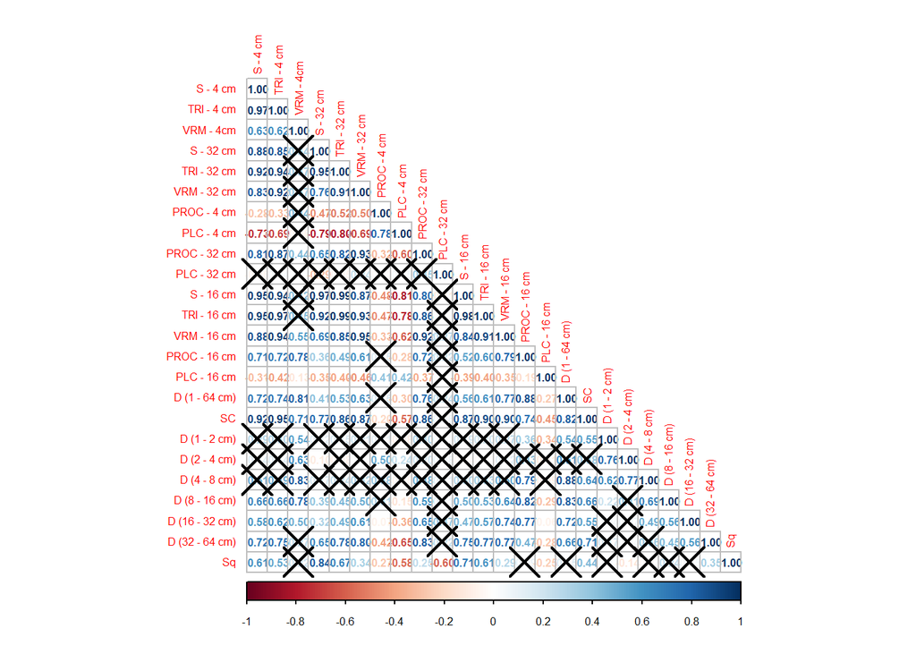

```r
#####################Correlation between metrics################################
metrics_cor<-cor(metrics) #Get correlation matrix composed of every metric pair.

###Corrplot adjustment
metrics_pub<-metrics
colnames(metrics_pub)<-c('S - 4 cm', 'TRI - 4 cm', 'VRM - 4cm', 'S - 32 cm',
                         'TRI - 32 cm', 'VRM - 32 cm', 'PROC - 4 cm', 'PLC - 4 cm',
                         'PROC - 32 cm', 'PLC - 32 cm', 'S - 16 cm', 'TRI - 16 cm',
                         'VRM - 16 cm', 'PROC - 16 cm', 'PLC - 16 cm', 'D (1 - 64 cm)',
                         'SC', 'D (1 - 2 cm)', 'D (2 - 4 cm)', 'D (4 - 8 cm)', 'D (8 - 16 cm)',
                         'D (16 - 32 cm)', 'D (32 - 64 cm)', 'Sq')
metrics_cor<-cor(metrics_pub)
#corrplot(metrics_cor, method='number',
#         type='lower')
res<-cor.mtest(metrics_cor,
               conf.level = .95)
#########################Displaying Corrplot#############################

corrplot(metrics_cor, method='number',
         type='lower', p.mat = res$p,
         sig.level = .05, tl.cex=0.5, cl.cex=0.5,
         number.cex=0.5)
```

```r
#######################################################
```

## Use VIF to remove collinearity

Removing complexity metrics greatly contributing to collinearity by using variance inflation factor (VIF).

```r
###############Use usdm for stepwise VIF selection on metrics##################################
library(usdm)
v1<-vifstep(metrics, th=10)
metrics_selected<-exclude(metrics, v1)
metrics_selected #See metrics retained from selection
```

```
##              V4      PLC4    PROC32     PLC32    PLC16     D1_2     D2_4
## 82.5 0.03972595  9.242265 0.3542356 1.3609894 5.380102 2.059848 2.059313
## BT   0.06354869 18.462807 0.3869983 1.5433599 5.696730 2.105806 2.136347
## CCG  0.08002010 14.839175 0.2802628 1.0273676 3.184027 2.196623 2.187020
## CJ   0.07057097 12.282814 0.4881684 1.8387325 3.296366 2.105106 2.102707
## CK   0.05272271  8.519395 0.6309607 1.9138448 3.775512 2.125388 2.149982
## DaBS 0.04697374 15.539315 0.2659814 1.9673836 3.822742 2.102362 2.106039
## DC   0.07477847 17.502046 0.4166059 2.3384137 5.065466 2.175885 2.184300
## DiBS 0.04879224 13.948038 0.3448847 1.5995921 3.319096 2.146635 2.144978
## FNL  0.09231118 14.027762 0.5720152 1.8826472 3.643584 2.173418 2.185573
## GGB  0.06445081 14.743830 0.4614089 2.2478442 4.286704 2.142029 2.141366
## GW   0.04763611 15.339935 0.2874124 3.1911692 4.278659 2.125547 2.134165
## HBH  0.06507814 14.385386 0.5483947 1.7884567 3.607074 2.179179 2.169388
## HR   0.09157567 14.738506 0.5034706 2.2121285 4.682016 2.186643 2.206191
## HS   0.06418384 11.639053 0.7444362 2.4561036 3.899267 2.116186 2.117397
## JH   0.06854386 12.926524 0.5524131 1.9177405 3.275951 2.123935 2.120539
## JLS  0.08996626 13.711100 0.5674756 2.0121217 3.471119 2.213680 2.187870
## JMZ  0.10180321 13.580160 0.6749426 2.6838572 4.000385 2.147930 2.145423
## JQ   0.05014038 12.100439 0.5099651 2.0976212 2.811581 2.123612 2.102982
## LD   0.09773878 15.983127 0.2414503 0.8735963 4.529776 2.114213 2.142355
## LDS  0.07129418 18.708382 0.4316027 2.6060655 3.972630 2.117886 2.169715
## MYS  0.03591826 21.839115 0.1743400 1.7492916 4.682573 2.108662 2.116179
## SL   0.08072169 10.510869 0.5701214 1.8626170 3.517852 2.255038 2.152829
## TL   0.04717792 14.914221 0.2674686 1.8916910 4.247381 2.136491 2.124769
## TS   0.08013721 14.234224 0.4679286 2.5597380 4.639967 2.134288 2.130212
## YY   0.05256534 17.972904 0.2521757 1.9701828 5.083402 2.136654 2.139941
##         D8_16   D16_32   D32_64      VRSD4
## 82.5 2.048714 2.075094 2.247949 0.69667321
## BT   2.146462 2.134220 2.187176 0.35940599
## CCG  2.157569 2.034047 2.140841 0.57198211
## CJ   2.165645 2.097948 2.238046 0.46889336
## CK   2.136556 2.170571 2.341126 0.36621178
## DaBS 2.097096 2.125669 2.214526 0.17148500
## DC   2.144677 2.146597 2.195416 0.21552578
## DiBS 2.093201 2.055113 2.128465 0.27035985
## FNL  2.164326 2.171833 2.256766 0.32194592
## GGB  2.153132 2.114266 2.312947 0.35606082
## GW   2.092675 2.130449 2.179806 0.09572413
## HBH  2.094460 2.137286 2.292320 0.47868320
## HR   2.160204 2.106320 2.213140 0.29349338
## HS   2.185740 2.188789 2.338200 0.31157591
## JH   2.148578 2.156038 2.229615 0.49583007
## JLS  2.171962 2.132067 2.255832 0.51166963
## JMZ  2.197287 2.243912 2.308156 0.32193789
## JQ   2.138418 2.138883 2.238538 0.47133979
## LD   2.182984 2.173301 2.164168 0.49713277
## LDS  2.149087 2.092245 2.201565 0.17018665
## MYS  2.059969 2.003714 2.069643 0.10205495
## SL   2.106764 2.121427 2.303921 0.35146390
## TL   2.065154 2.127289 2.087826 0.26951771
## TS   2.128885 2.163362 2.132155 0.22094171
## YY   2.055983 2.084683 2.153331 0.17385214
```

```r
####################################################################################
```

## Comparison of complexity metrics (Latitudinal correlation)

Latitudinal correlation of each complexity metric.

```r
##Latitudinal correlation of metrics###
library(readxl)
#Import latitudes of sites
coordi<-read_xlsx('Data/coordinates.xlsx')
coordi<-as.data.frame(coordi)
#coordi<-coordi[,-4]
row.names(coordi)<-coordi[,1]
#Merge latitudes and metrics
metrics_coordi<-merge(metrics, coordi,
                      by='row.names')
row.names(metrics_coordi)<-metrics_coordi[,1]
metrics_coordi<-metrics_coordi[-1]

metrics_coordi<-merge(metrics_coordi, as.data.frame(raw_metrics[26]),
                      by='row.names')
metrics_coordi$region<-factor(metrics_coordi$region,
                              levels=c('KT','LY','LD',
                                       'EC','NC'),
                              ordered = T)
```

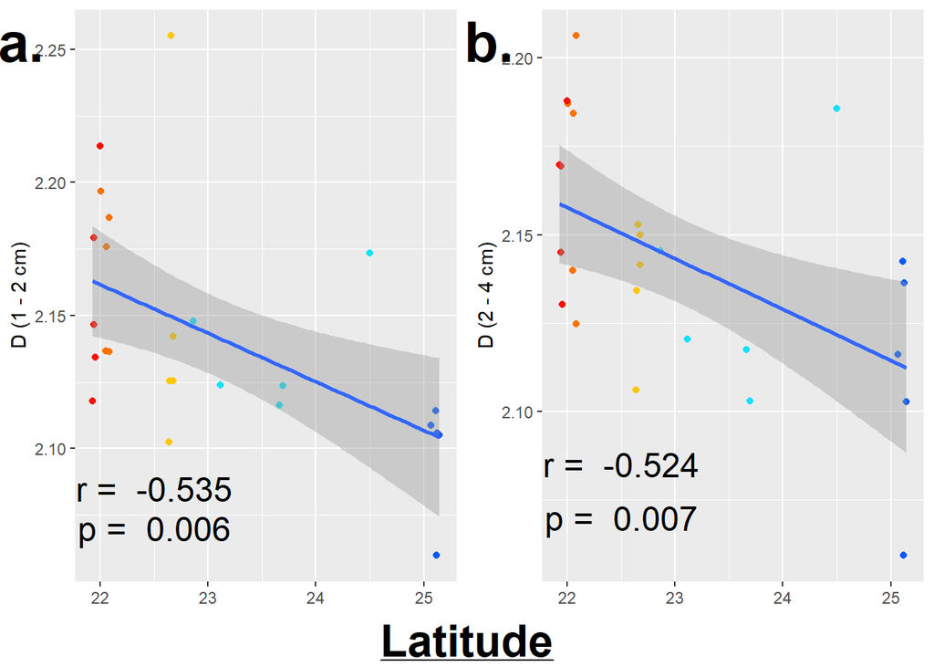

```r
#V4
cor_v4_lat<-cor.test(metrics_coordi$Lat, metrics_coordi$V4, method='pearson',
         conf.level = 0.95)

#Plot the relationship with latitudes
library(ggplot2)
plot_v4_lat<-ggplot(data=metrics_coordi, aes(x=Lat, y=V4))+
  geom_point(aes(col=region))+
  geom_smooth(method='lm')+
  annotate('text', x=22.5, y=0.037, size=5,label=paste('p = ',round(cor_v4_lat$p.value, 3)))+
  annotate('text', x=22.5, y=0.043, size=5,label=paste('r = ',round(cor_v4_lat$estimate, 3)))+
  xlab('Latitudes')+ ylab('VRM - 4 cm')+
  guides(color = guide_legend(title = "Region"))+
  scale_color_manual(values=c( "#fc0f00",  "#fb7200","#fec700", "#15e0fa","#0c59fe" ))


#PROC32
cor_PROC32_lat<-cor.test(metrics_coordi$Lat, metrics_coordi$PROC32, method='pearson',
                      conf.level = 0.95)

#Plot the relationship with latitudes
plot_PROC32_lat<-ggplot(data=metrics_coordi, aes(x=Lat, y=PROC32))+
  geom_point(aes(col=region))+
  geom_smooth(method='lm')+
  annotate('text', x=24.5, y=0.135, size=5, label=paste('p = ',round(cor_PROC32_lat$p.value, 3)))+
  annotate('text', x=24.5, y=0.175, size=5, label=paste('r = ',round(cor_PROC32_lat$estimate, 3)))+
  xlab('Latitudes')+ ylab('PROC - 32 cm')+
  guides(color = guide_legend(title = "Region"))+
  scale_color_manual(values=c( "#fc0f00",  "#fb7200","#fec700", "#15e0fa","#0c59fe" ))


#PLC4
cor_PLC4_lat<-cor.test(metrics_coordi$Lat, metrics_coordi$PLC4, method='pearson',
                      conf.level = 0.95)

#Plot the relationship
plot_PLC4_lat<-ggplot(data=metrics_coordi, aes(x=Lat, y=PLC4))+
  geom_point(aes(col=region))+
  geom_smooth(method='lm')+
  annotate('text', x=22.5, y=3, size=5,label=paste('p = ',round(cor_PLC4_lat$p.value, 3)))+
  annotate('text', x=22.5, y=5, size=5, label=paste('r = ',round(cor_PLC4_lat$estimate, 3)))+
  xlab('Latitudes')+ ylab('PLC - 4 cm')+
  guides(color = guide_legend(title = "Region"))+
  scale_color_manual(values=c( "#fc0f00",  "#fb7200","#fec700", "#15e0fa","#0c59fe" ))




#PLC16
cor_PLC16_lat<-cor.test(metrics_coordi$Lat, metrics_coordi$PLC16, method='pearson',
                     conf.level = 0.95)

#Plot relationship
plot_PLC16_lat<-ggplot(data=metrics_coordi, aes(x=Lat, y=PLC16))+
  geom_point(aes(col=region))+
  geom_smooth(method='lm')+
  annotate('text', x=22.5, y=2.9,size=5, label=paste('p = ',round(cor_PLC16_lat$p.value, 3)))+
  annotate('text', x=22.5, y=3.2, size=5,label=paste('r = ',round(cor_PLC16_lat$estimate, 3)))+
  xlab('Latitudes')+ ylab('PLC - 16 cm')+
  guides(color = guide_legend(title = "Region"))+
  scale_color_manual(values=c( "#fc0f00",  "#fb7200","#fec700", "#15e0fa","#0c59fe" ))


#PLC32
cor_PLC32_lat<-cor.test(metrics_coordi$Lat, metrics_coordi$PLC32, method='pearson',
                                              conf.level = 0.95)

#no significant correlation btw sc and latitude
plot_PLC32_lat<-ggplot(data=metrics_coordi, aes(x=Lat, y=PLC32))+
  geom_point(aes(col=region))+
  geom_smooth(method='lm')+
  annotate('text', x=22.6, y=1, size=5,label=paste('p = ',round(cor_PLC32_lat$p.value, 3)))+
  annotate('text', x=22.6, y=1.2, size=5,label=paste('r = ',round(cor_PLC32_lat$estimate, 3)))+
  xlab('Latitudes')+ ylab('PLC - 32 cm')+
  guides(color = guide_legend(title = "Region"))+
  scale_color_manual(values=c( "#fc0f00",  "#fb7200","#fec700", "#15e0fa","#0c59fe" ))


#D12

cor_D12_lat<-cor.test(metrics_coordi$Lat, metrics_coordi$D1_2, method='pearson',
                     conf.level = 0.95)

#Plot relationship
plot_D12_lat<-ggplot(data=metrics_coordi, aes(x=Lat, y=D1_2))+
  geom_point(aes(col=region))+
  geom_smooth(method='lm')+
  annotate('text', x=22.5, y=2.07,size=6.5, label=paste('p = ',round(cor_D12_lat$p.value, 3)))+
  annotate('text', x=22.5, y=2.085, size=6.5,label=paste('r = ',round(cor_D12_lat$estimate, 3)))+
  xlab('Latitudes')+ ylab('D (1 - 2 cm)')+
  guides(color = guide_legend(title = "Region"))+
  scale_color_manual(values=c( "#fc0f00",  "#fb7200","#fec700", "#15e0fa","#0c59fe" ))




#D24
cor_D24_lat<-cor.test(metrics_coordi$Lat, metrics_coordi$D2_4, method='pearson',
                        conf.level = 0.95)

#Plot relationship
plot_D24_lat<-ggplot(data=metrics_coordi, aes(x=Lat, y=D2_4))+
  geom_point(aes(col=region))+
  geom_smooth(method='lm')+
  annotate('text', x=22.5, y=2.07, size=6.5, label=paste('p = ',round(cor_D24_lat$p.value, 3)))+
  annotate('text', x=22.5, y=2.085, size=6.5, label=paste('r = ',round(cor_D24_lat$estimate, 3)))+
  xlab('Latitudes')+ ylab('D (2 - 4 cm)')+
  guides(color = guide_legend(title = "Region"))+
  scale_color_manual(values=c( "#fc0f00",  "#fb7200","#fec700", "#15e0fa","#0c59fe" ))



#D816

cor_D816_lat<-cor.test(metrics_coordi$Lat, metrics_coordi$D8_16, method='pearson',
                      conf.level = 0.95)

#Plot relationship
plot_D816_lat<-ggplot(data=metrics_coordi, aes(x=Lat, y=D8_16))+
  geom_point(aes(col=region))+
  geom_smooth(method='lm')+
  annotate('text', x=23, y=2.057, size=5,label=paste('p = ',round(cor_D816_lat$p.value, 3)))+
  annotate('text', x=23, y=2.07, size=5,label=paste('r = ',round(cor_D816_lat$estimate, 3)))+
  xlab('Latitudes')+ ylab('D (8 - 16 cm)')+
  guides(color = guide_legend(title = "Region"))+
  scale_color_manual(values=c( "#fc0f00",  "#fb7200","#fec700", "#15e0fa","#0c59fe" ))


#D1632
cor_D1632_lat<-cor.test(metrics_coordi$Lat, metrics_coordi$D16_32, method='pearson',
                      conf.level = 0.95)


#Plot relationship
plot_D1632_lat<-ggplot(data=metrics_coordi, aes(x=Lat, y=D16_32))+
  geom_point(aes(col=region))+
  geom_smooth(method='lm')+
  annotate('text', x=23, y=2.02,size=5, label=paste('p = ',round(cor_D1632_lat$p.value, 3)))+
  annotate('text', x=23, y=2.04, size=5,label=paste('r = ',round(cor_D1632_lat$estimate, 3)))+
  xlab('Latitudes')+ ylab('D (16 - 32 cm)')+
  guides(color = guide_legend(title = "Region"))+
  scale_color_manual(values=c( "#fc0f00",  "#fb7200","#fec700", "#15e0fa","#0c59fe" ))



#D3264
cor_D3264_lat<-cor.test(metrics_coordi$Lat, metrics_coordi$D32_64, method='pearson',
                      conf.level = 0.95)

#Plot relationship
plot_D3264_lat<-ggplot(data=metrics_coordi, aes(x=Lat, y=D32_64))+
  geom_point(aes(col=region))+
  geom_smooth(method='lm')+
  annotate('text', x=23, y=2.07, size=5,label=paste('p = ',round(cor_D3264_lat$p.value, 3)))+
  annotate('text', x=23, y=2.09, size=5,label=paste('r = ',round(cor_D3264_lat$estimate, 3)))+
  xlab('Latitudes')+ ylab('D (32 - 64 cm)')+
  guides(color = guide_legend(title = "Region"))+
  scale_color_manual(values=c( "#fc0f00",  "#fb7200","#fec700", "#15e0fa","#0c59fe" ))



#Sq

cor_VRSD_lat<-cor.test(metrics_coordi$Lat, metrics_coordi$VRSD4, method='pearson',
                       conf.level = 0.95)

#Plot relationship
plot_VRSD_lat<-ggplot(data=metrics_coordi, aes(x=Lat, y=VRSD4))+
  geom_point(aes(col=region))+
  geom_smooth(method='lm')+
  annotate('text', x=23.5, y=0.15, size=5,label=paste('p = ',round(cor_VRSD_lat$p.value, 3)))+
  annotate('text', x=23.5, y=0.18, size=5,label=paste('r = ',round(cor_VRSD_lat$estimate, 3)))+
  labs(y='Sq')+xlab('Latitudes')+
  guides(color = guide_legend(title = "Region"))+
  scale_color_manual(values=c( "#fc0f00",  "#fb7200","#fec700", "#15e0fa","#0c59fe" ))

library(ggpubr)
library(grid)

Arrange1<-ggarrange(plot_D12_lat + rremove("xlab"),
                    plot_D24_lat + rremove("xlab"),
                  legend = 'none',
                    ncol=2, nrow=1,
                    labels=c('a.', 'b.'),
                  hjust=0.05,

                  font.label=list(face='bold', size= 30)
                  )
Arrange1<-annotate_figure(Arrange1,
                bottom = textGrob(expression(bold(underline("Latitude"))), gp = gpar(cex = 2)))

Arrange1
```

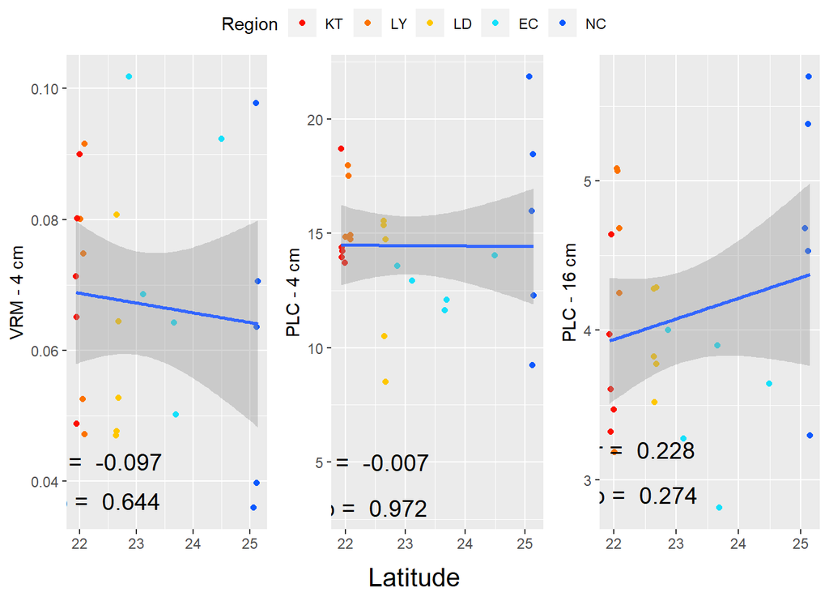

```r
Arrange2<-ggarrange(plot_v4_lat+rremove("xlab"),
                    plot_PLC4_lat+rremove('xlab'),
                    plot_PLC16_lat+rremove('xlab'),

                    common.legend = T,
                    ncol=3, nrow=1
                    )
Arrange2<-annotate_figure(Arrange2,
                          bottom = textGrob("Latitude", gp = gpar(cex = 1.3)))

Arrange2
```

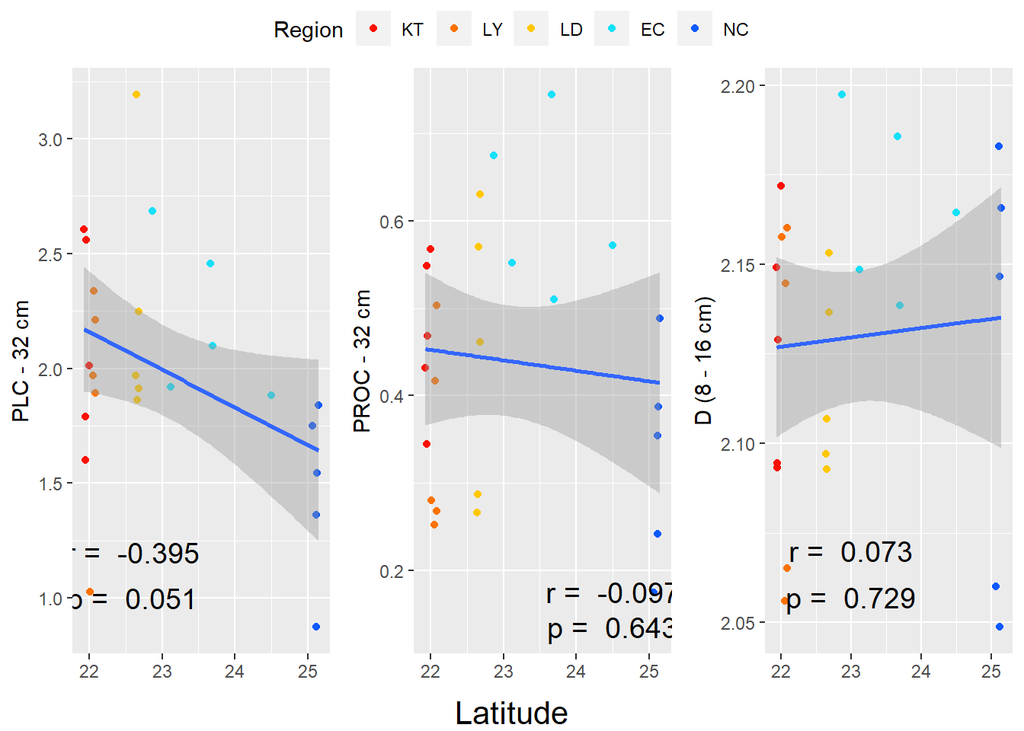

```r
Arrange2_1<-ggarrange(
  plot_PLC32_lat+rremove('xlab'),
  plot_PROC32_lat+rremove('xlab'),
                    plot_D816_lat+rremove('xlab'),

           common.legend = T,
                    ncol=3, nrow=1
           )
Arrange2_1<-annotate_figure(Arrange2_1,
                          bottom = textGrob("Latitude", gp = gpar(cex = 1.3)))
Arrange2_1
```

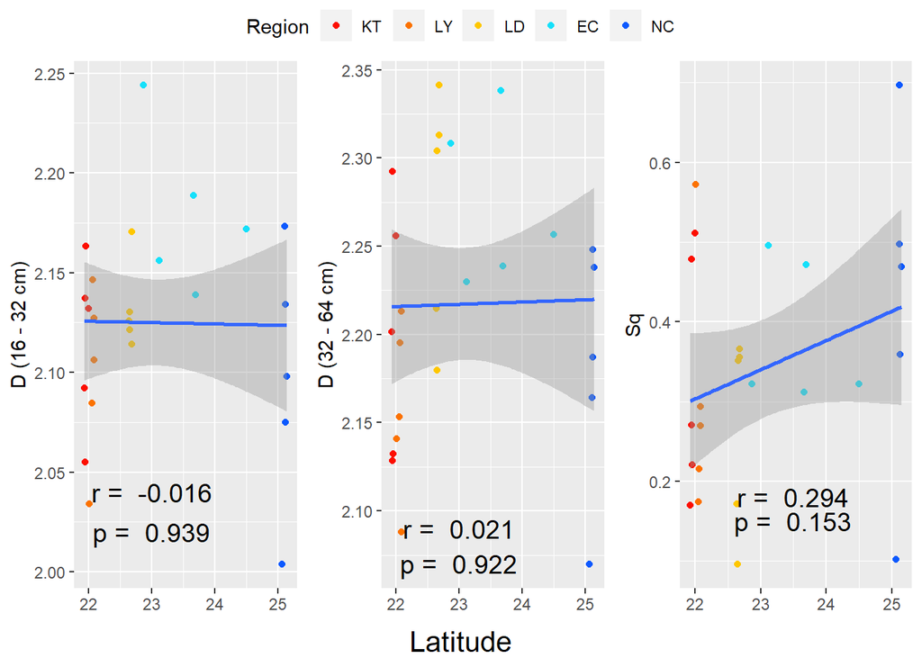

```r
Arrange2_2<-ggarrange( plot_D1632_lat+rremove('xlab'),
                    plot_D3264_lat+rremove('xlab'),
                    plot_VRSD_lat+rremove('xlab'),
           common.legend = T,
                    ncol=3, nrow=1
           )
Arrange2_2<-annotate_figure(Arrange2_2,
                          bottom = textGrob("Latitude", gp = gpar(cex = 1.3)))
Arrange2_2
```

## Comparison of complexity metrics (Interregional differences)

Regional comparison in complexity based on PERMANOVA.

```r
###################PERMANOVA based on metrics#########################
library(vegan)
set.seed(123)
metr_sel_std<-decostand(metrics_selected, 'standardize')
region<-c('NC', 'NC', 'LY', 'NC', 'LD', 'LD', 'LY', 'KT', 'EC', 'LD', 'LD', 'KT', 'LY',
       'EC', 'EC', 'KT', 'EC', 'EC', 'NC', 'KT', 'NC', 'LD', 'LY', 'KT', 'LY')

#PERMANOVA on complexity
metr_sel_euc<-vegdist(metr_sel_std, 'euclidean')

metr_sel_region<-cbind(metr_sel_std, region)

metr_sel_PERMANOVA<-adonis2(metr_sel_std~region, data=metr_sel_region,
                            permutations = 9999, method='euclidean')

metr_sel_PERMANOVA
```

```
## Permutation test for adonis under reduced model
## Terms added sequentially (first to last)
## Permutation: free
## Number of permutations: 9999
##
## adonis2(formula = metr_sel_std ~ region, data = metr_sel_region, permutations = 9999, method = "euclidean")
##          Df SumOfSqs      R2      F Pr(>F)
## region    4   79.403 0.30077 2.1507 0.0058 **
## Residual 20  184.597 0.69923
## Total    24  264.000 1.00000
## ---
## Signif. codes:  0 '***' 0.001 '**' 0.01 '*' 0.05 '.' 0.1 ' ' 1
```

```r
library(RVAideMemoire)
library(devtools)
library(pairwiseAdonis)
#Pairwise permutation test
permtest<-pairwise.adonis(as.data.frame(metr_sel_std), metr_sel_region$region,
                          sim.method='euclidean', p.adjust.m = 'BH', perm=9999)

permtest
```

```
##       pairs Df SumsOfSqs   F.Model         R2 p.value p.adjusted sig
## 1  NC vs LY  1 18.073987 1.4886286 0.15688554  0.1748  0.2185000
## 2  NC vs LD  1 24.458873 2.0412194 0.20328402  0.0482  0.1304000
## 3  NC vs KT  1 22.735702 2.0112769 0.20090113  0.0601  0.1304000
## 4  NC vs EC  1 40.543429 3.8963060 0.32752234  0.0083  0.0460000   .
## 5  LY vs LD  1 16.265992 1.8171799 0.18510202  0.1142  0.1688571
## 6  LY vs KT  1  6.092433 0.7364361 0.08429479  0.6042  0.6042000
## 7  LY vs EC  1 35.726801 4.8447359 0.37717676  0.0092  0.0460000   .
## 8  LD vs KT  1  6.845284 0.8436414 0.09539525  0.4845  0.5383333
## 9  LD vs EC  1 13.040902 1.8073536 0.18428555  0.1182  0.1688571
## 10 KT vs EC  1 14.723812 2.2523459 0.21969078  0.0652  0.1304000
```

Examining the disparity between regions by using nonparametric test.

```r
##########################Interregional comparisons: Kruskal Wallis test##############################


V4_kruskal<-kruskal.test(V4~region, data=metrics_coordi)
V32_kruskal<-kruskal.test(V32~region, data=metrics_coordi)
PROC32_kruskal<-kruskal.test(PROC32~region, data=metrics_coordi)
PLC4_kruskal<-kruskal.test(PLC4~region, data=metrics_coordi)
PLC16_kruskal<-kruskal.test(PLC16~region, data=metrics_coordi)
PLC32_kruskal<-kruskal.test(PLC32~region, data=metrics_coordi)
D12_kruskal<-kruskal.test(D1_2~region, data=metrics_coordi)
D24_kruskal<-kruskal.test(D2_4~region, data=metrics_coordi)
D48_kruskal<-kruskal.test(D4_8~region, data=metrics_coordi)
D816_kruskal<-kruskal.test(D8_16~region, data=metrics_coordi)
D1632_kruskal<-kruskal.test(D16_32~region, data=metrics_coordi)
D3264_kruskal<-kruskal.test(D32_64~region, data=metrics_coordi)
VRSD_kruskal<-kruskal.test(VRSD4~region, data=metrics_coordi)

######################Pairwise Dunn test########################################
library(PMCMRplus)
PROC32_DT<-kwAllPairsDunnTest(PROC32~region, data=metrics_coordi, method='bh')
#Significance at EC-LY, EC-NC
D3264_DT<-kwAllPairsDunnTest(D32_64~region, data=metrics_coordi, method="bh")
#Significance may exist at EC-LY
D12_DT<-kwAllPairsDunnTest(D1_2~region, data=metrics_coordi, method="bh")
#Significance at LY-NC, KT-NC

#Show significant pairs
library(rcompanion)
library(rempsyc)
PROC32_DT<-PMCMRTable(PROC32_DT)
D3264_DT<-PMCMRTable(D3264_DT)
D12_DT<-PMCMRTable(D12_DT)
DT_sum<-cbind(D12_DT, D3264_DT, PROC32_DT)
DT_sum[c(3,5)]<-NULL
colnames(DT_sum)[2:4]<-c('p.value of D (1 - 2 cm) cm', 'p.value of D (32 - 64 cm)', 'p.value of PROC - 32 cm')

DT_NT<-nice_table(DT_sum)
DT_NT
```

| Comparison | p.value of D (1 - 2 cm) cm | p.value of D (32 - 64 cm) | p.value of PROC - 32 cm |
| --- | --- | --- | --- |
| LY - KT = 0 | 1 | 1 | 0.928 |
| LD - KT = 0 | 1 | 0.72 | 1 |
| EC - KT = 0 | 1 | 0.563 | 0.928 |
| NC - KT = 0 | 0.0537 | 1 | 0.928 |
| LD - LY = 0 | 1 | 0.163 | 0.928 |
| EC - LY = 0 | 1 | 0.0994 | 0.0411 |
| NC - LY = 0 | 0.0127 | 1 | 1 |
| EC - LD = 0 | 1 | 1 | 0.75 |
| NC - LD = 0 | 0.348 | 0.547 | 0.928 |
| NC - EC = 0 | 0.411 | 0.385 | 0.0263 |

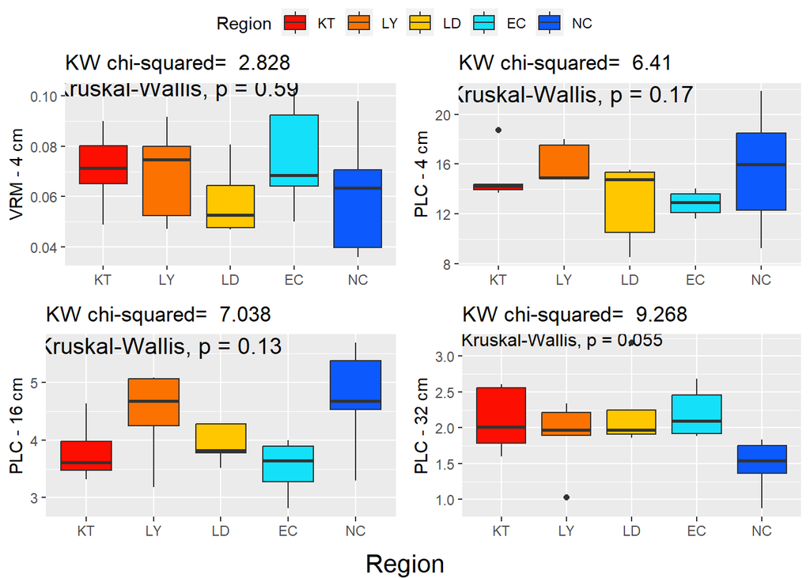

```r
#flextable::save_as_docx(DT_NT, path = "Figures/PairwiseComparison_indicators_Dunn.docx")


####Plot relationships between regions###
library(ggpubr)
#V4
box_V4_region<-ggplot(data=metrics_coordi,
                      aes(x=region, y=V4 ))+
  geom_boxplot(aes(fill=region))+
 ggtitle(label =paste('KW chi-squared= ', round(V4_kruskal$statistic, 3)))+
  labs(y='VRM - 4 cm')+xlab('Region')+
  guides(fill = guide_legend(title = "Region"))+
  scale_fill_manual(values=c( "#fc0f00",  "#fb7200","#fec700", "#15e0fa","#0c59fe" ))+
  stat_compare_means(label.y = 0.1, cex=5)



#PROC32

box_PROC32_region<-ggplot(data=metrics_coordi,
                       aes(x=region, y=PROC32 ))+
  geom_boxplot(aes(fill=region))+
  ggtitle(label = paste('KW chi-squared= ', round(PROC32_kruskal$statistic, 3)))+
  labs(y='PROC - 32 cm')+xlab('Region')+
  guides(fill = guide_legend(title = "Region"))+
  scale_fill_manual(values=c( "#fc0f00",  "#fb7200","#fec700", "#15e0fa","#0c59fe" ))


box_PROC32_region<-box_PROC32_region+
  stat_compare_means(label.y = 0.17, cex=5)+ # Add global p-value
  annotate('text', x=1:5, y=0.75, label=c('ns', '*', 'ns', '', '*'),
           cex=5)


#PLC4

box_PLC4_region<-ggplot(data=metrics_coordi,
                         aes(x=region, y=PLC4 ))+
  geom_boxplot(aes(fill=region))+
  ggtitle(label =paste('KW chi-squared= ', round(PLC4_kruskal$statistic, 3)))+
  labs(y='PLC - 4 cm')+xlab('Region')+
  guides(fill = guide_legend(title = "Region"))+
  scale_fill_manual(values=c( "#fc0f00",  "#fb7200","#fec700", "#15e0fa","#0c59fe" ))+
  stat_compare_means(label.y = 21, cex=5)


#PLC16
box_PLC16_region<-ggplot(data=metrics_coordi,
                      aes(x=region, y=PLC16 ))+
  geom_boxplot(aes(fill=region))+
  ggtitle(label =paste('KW chi-squared= ', round(PLC16_kruskal$statistic, 3)))+
  labs(y='PLC - 16 cm')+xlab('Region')+
  guides(fill = guide_legend(title = "Region"))+
  scale_fill_manual(values=c( "#fc0f00",  "#fb7200","#fec700", "#15e0fa","#0c59fe" ))+
  stat_compare_means(label.y = 5.5, cex=5)


#PLC32
box_PLC32_region<-ggplot(data=metrics_coordi,
                      aes(x=region, y=PLC32 ))+
  geom_boxplot(aes(fill=region))+
  ggtitle(label =paste('KW chi-squared= ', round(PLC32_kruskal$statistic, 3)))+
  labs(y='PLC - 32 cm')+xlab('Region')+
  guides(fill = guide_legend(title = "Region"))+
  scale_fill_manual(values=c( "#fc0f00",  "#fb7200","#fec700", "#15e0fa","#0c59fe" ))+
  stat_compare_means(label.y =3.15, cex=4)



#D12
box_D12_region<-ggplot(data=metrics_coordi,
                      aes(x=region, y=D1_2 ))+
  geom_boxplot(aes(fill=region))+
  ggtitle(label =paste('KW chi-squared= ', round(D12_kruskal$statistic, 3)))+
  labs(y='D(1 - 2 cm)')+xlab('Region')+
  guides(fill = guide_legend(title = "Region"))+
  scale_fill_manual(values=c( "#fc0f00",  "#fb7200","#fec700", "#15e0fa","#0c59fe" ))


box_D12_region<-box_D12_region+
  stat_compare_means(label.y = 2.32, cex=5)+ # Add global p-value
  annotate('text', x=1:5, y=2.28, label=c('ns', '*', 'ns','ns',''),
           cex=5)



#D24

box_D24_region<-ggplot(data=metrics_coordi,
                       aes(x=region, y=D2_4 ))+
  geom_boxplot(aes(fill=region))+
  ggtitle(label =paste('KW chi-squared= ', round(D24_kruskal$statistic, 3)))+
  labs(y='D(2 - 4 cm) cm')+xlab('Region')+
  guides(fill = guide_legend(title = "Region"))+
  scale_fill_manual(values=c( "#fc0f00",  "#fb7200","#fec700", "#15e0fa","#0c59fe" ))+
  stat_compare_means(label.y = 2.06, cex=5)




#D816
box_D816_region<-ggplot(data=metrics_coordi,
                       aes(x=region, y=D8_16 ))+
  geom_boxplot(aes(fill=region))+
  ggtitle(label =paste('KW chi-squared= ', round(PLC4_kruskal$statistic, 3)))+
  labs(y='D(8 - 16 cm)')+xlab('Region')+
  guides(fill = guide_legend(title = "Region"))+
  scale_fill_manual(values=c( "#fc0f00",  "#fb7200","#fec700", "#15e0fa","#0c59fe" ))+
  stat_compare_means(label.y = 2.19, cex=5)



#D1632
box_D1632_region<-ggplot(data=metrics_coordi,
                        aes(x=region, y=D16_32 ))+
  geom_boxplot(aes(fill=region))+
  ggtitle(label =paste('KW chi-squared= ', round(PLC4_kruskal$statistic, 3)))+
  labs(y='D(16 - 32 cm)')+xlab('Region')+
  guides(fill = guide_legend(title = "Region"))+
  scale_fill_manual(values=c( "#fc0f00",  "#fb7200","#fec700", "#15e0fa","#0c59fe" ))+
  stat_compare_means(label.y = 2.23, cex=5)



#D3264
box_D3264_region<-ggplot(data=metrics_coordi,
                         aes(x=region, y=D32_64 ))+
  geom_boxplot(aes(fill=region))+
  ggtitle(label =paste('KW chi-squared= ', round(PLC4_kruskal$statistic, 3)))+
  labs(y='D(32 - 64 cm)')+xlab('Region')+
  guides(fill = guide_legend(title = "Region"))+
  scale_fill_manual(values=c( "#fc0f00",  "#fb7200","#fec700", "#15e0fa","#0c59fe" ))

box_D3264_region<-box_D3264_region+
  stat_compare_means(label.y = 2.4, cex=5)+ # Add global p-value
  # Pairwise comparison against reference
  annotate('text', x=1:5, y=2.36, label=c('ns', 'ns', 'ns', '', 'ns'),
           cex=5)


#Sq
box_VRSD_region<-ggplot(data=metrics_coordi,
                         aes(x=region, y=VRSD4 ))+
  geom_boxplot(aes(fill=region))+
  ggtitle(label =paste('KW chi-squared= ', round(PLC4_kruskal$statistic, 3)))+
  labs(y='Sq')+xlab('Region')+
  guides(fill = guide_legend(title = "Region"))+
  scale_fill_manual(values=c( "#fc0f00",  "#fb7200","#fec700", "#15e0fa","#0c59fe" ))

box_VRSD_region<-box_VRSD_region+
  stat_compare_means(label.y = 0.65, cex=5)


Arrange3<-ggarrange(box_V4_region+rremove("xlab"),
                   box_PLC4_region+rremove('xlab'),
                    box_PLC16_region+rremove('xlab'),
                    box_PLC32_region+rremove('xlab'),

                    common.legend = T,
                    ncol=2, nrow=2
                    )
Arrange3<-annotate_figure(Arrange3,
                          bottom = textGrob("Region", gp = gpar(cex = 1.3)))
Arrange3
```

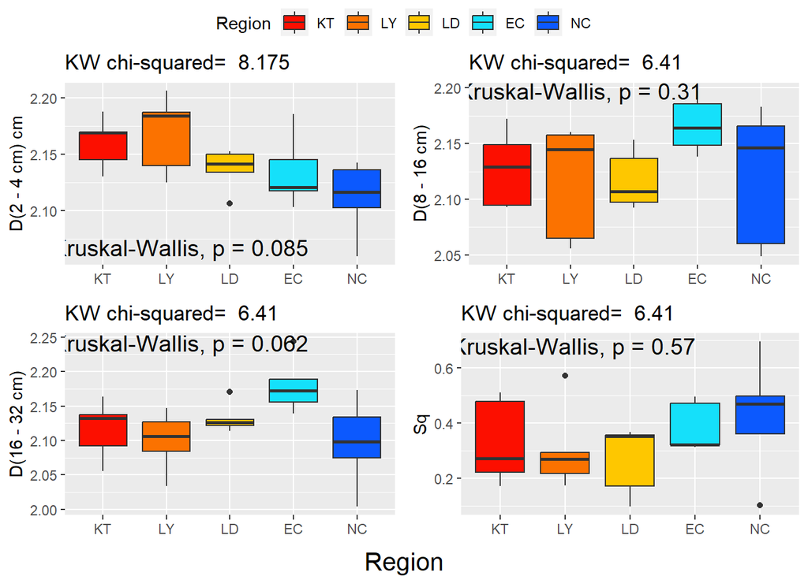

```r
Arrange3_1<-ggarrange(box_D24_region+rremove('xlab'),
                    box_D816_region+rremove('xlab'),
                    box_D1632_region+rremove('xlab'),
                    box_VRSD_region+rremove('xlab'),
                    common.legend = T,
                    ncol=2, nrow=2
                    )
Arrange3_1<-annotate_figure(Arrange3_1,
                          bottom = textGrob("Region", gp = gpar(cex = 1.3)))
Arrange3_1
```

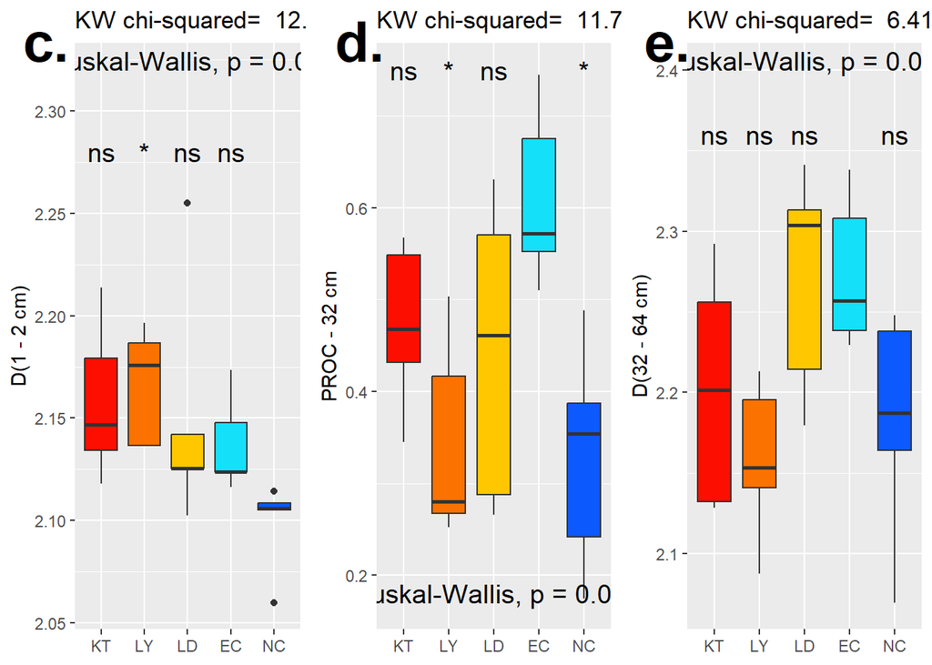

```r
Arrange4<-ggarrange(box_D12_region+  rremove("xlab"),
  box_PROC32_region + rremove("xlab"),
                    box_D3264_region + rremove("xlab"),
                    common.legend=T, legend = 'none',
                    ncol=3, nrow=1,
                    labels=c('c.', 'd.', 'e.'),
  font.label=list(face='bold', size= 30)
)
Arrange4
```

## PCA based on benthic composition

Applying principle component analysis to display relationships between sites in benthic composition.

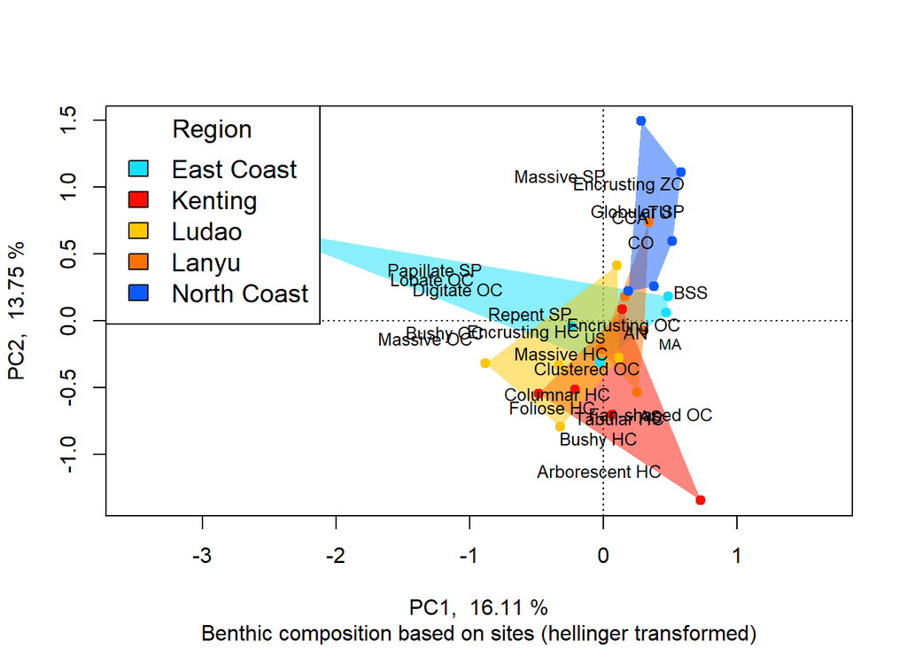

```r
##Combine metrics with composition
#Import metrics
comp_sub_metrics<-merge(composition_substrates, metrics, by='row.names')
row.names(comp_sub_metrics)<-comp_sub_metrics$Row.names
comp_sub_metrics<-comp_sub_metrics[,-1]
#Change colnames
indicators<-c('S - 4 cm', 'TRI - 4 cm', 'VRM - 4 cm',
              'S - 32 cm', 'TRI - 32 cm', 'VRM - 32 cm',
              'PROC - 4 cm', 'PLC - 4 cm', 'PROC - 32 cm',
              'PLC - 32 cm', 'S - 16 cm', 'TRI - 16 cm', 'VRM - 16 cm',
              'PROC - 16 cm', 'PLC - 16 cm', 'D(1 - 64 cm)', 'SC',
              'D (1 - 2 cm)', 'D (2 - 4 cm)', 'D (4 - 8 cm)',
              'D(8 - 16 cm)', 'D(16 - 32 cm)', 'D(32 - 64 cm)',
              'Sq')
colnames(comp_sub_metrics)[30:53]<-indicators


#####################PCA for composition#########################################
##############set color###########################

library(fishualize)
library(devtools)
#devtools::install_github("nschiett/fishualize", force = TRUE)
my_cols<-c("#15e0fa", "#fc0f00","#fec700",  "#fb7200" ,"#0c59fe" )

##########################tb-PCA (hellinger transformed)###########################################
comp_sub_hel<-decostand(composition_substrates[,3:29], method='hellinger')
comp_sub_hel<-decostand(comp_sub_hel, method='standardize')
colnames(comp_sub_hel)<-c('AN', 'Arborescent HC',
                          'Bushy HC', 'Columnar HC', 'Encrusting HC',
                          'Foliose HC', 'Massive HC', 'Tabular HC', 'Digitate OC',
                          'Lobate OC', 'Massive OC','TU', 'Bushy OC',
                          'AS','Fan-shaped OC', 'Encrusting ZO',
                          'Globular SP', 'Massive SP',
                          'Clustered OC','Encrusting OC', 'Repent SP',
                          'Papillate SP', 'CO', 'CCA',
                          'BSS', 'MA', 'US')
groups<-composition_substrates$region
comp_sub_RDA<-rda(comp_sub_hel)
RDA_summary<-summary(comp_sub_RDA)


#Visualization of PCA
ordiplot(comp_sub_RDA, type='n',
         display=c('site', 'sp'),
         scaling=3,
         xlab=paste('PC1, ',
                    round(RDA_summary$cont$importance[2,1]*100, 2), '%'),
         ylab=paste('PC2, ',round(RDA_summary$cont$importance[2,2]*100, 2), '%'),
        )
title(sub='Benthic composition based on sites (hellinger transformed)')
ordihull(comp_sub_RDA,
         groups=groups,
         draw='polygon',
         scaling=3,
         col=my_cols,
         border=NA,
         alpha=0.5)
groups2<-groups
groups2<-as.factor(groups2)
levels(groups2)<-my_cols
groups2<-as.vector(groups2)
points(comp_sub_RDA, display='site',
       scaling=3,
       col=groups2,
       pch=20, cex=1.5)
vct.scores<-scores(comp_sub_RDA,
                   choices=1:2,
                   display='sp',
                   scaling=3)
text(vct.scores[1,1],vct.scores[1,2],
     row.names(vct.scores)[1],
     col='black', cex=0.8)#actinia
text(vct.scores[2,1],vct.scores[2,2],
     row.names(vct.scores)[2],
     col='black', cex=0.8)#arborescent HC
text(vct.scores[3,1],vct.scores[3,2],
     row.names(vct.scores)[3],
     col='black', cex=0.8) #Bushy HC
text(vct.scores[4,1],vct.scores[4,2],
     row.names(vct.scores)[4],
     col='black', cex=0.8) #columnar HC
text(vct.scores[5,1],vct.scores[5,2],
     row.names(vct.scores)[5],
     col='black', cex=0.8) #encrusting HC
text(vct.scores[6,1],vct.scores[6,2],
     row.names(vct.scores)[6],
     col='black', cex=0.8) #foliose HC
text(vct.scores[7,1],vct.scores[7,2],
     row.names(vct.scores)[7],
     col='black', cex=0.8) #massive HC
text(vct.scores[8,1],vct.scores[8,2],
     row.names(vct.scores)[8],
     col='black', cex=0.8) #tabular HC
text(vct.scores[9,1],vct.scores[9,2],
     row.names(vct.scores)[9],
     col='black', cex=0.8) #digitate HC
text(vct.scores[10,1],vct.scores[10,2],
     row.names(vct.scores)[10],
     col='black', cex=0.8) #lobate OC
text(vct.scores[11,1],vct.scores[11,2],
     row.names(vct.scores)[11],
     col='black', cex=0.8) #massive OC
text(vct.scores[12,1],vct.scores[12,2],
     row.names(vct.scores)[12],
     col='black', cex=0.8) #filamentous algae
text(vct.scores[13,1],vct.scores[13,2],
     row.names(vct.scores)[13],
     col='black', cex=0.8) #bushy OC
text(vct.scores[14,1],vct.scores[14,2],
     row.names(vct.scores)[14],
     col='black', cex=0.8)#ascidian
text(vct.scores[15,1],vct.scores[15,2],
     row.names(vct.scores)[15],
     col='black', cex=0.8) #fan OC
text(vct.scores[16,1],vct.scores[16,2],
     row.names(vct.scores)[16],
     col='black', cex=0.8) #zoenc
text(vct.scores[17,1],vct.scores[17,2],
     row.names(vct.scores)[17],
     col='black', cex=0.8) #globular sponges
text(vct.scores[18,1],vct.scores[18,2],
     row.names(vct.scores)[18],
     col='black', cex=0.8)#spomas
text(vct.scores[19,1],vct.scores[19,2],
     row.names(vct.scores)[19],
     col='black', cex=0.8)#clustered OC
text(vct.scores[20,1],vct.scores[20,2],
     row.names(vct.scores)[20],
     col='black', cex=0.8) #ocenc
text(vct.scores[21,1],vct.scores[21,2],
     row.names(vct.scores)[21],
     col='black', cex=0.8) #ocenc
text(vct.scores[22,1],vct.scores[22,2],
     row.names(vct.scores)[22],
     col='black', cex=0.8) #spopap
text(vct.scores[23,1],vct.scores[23,2],
     row.names(vct.scores)[23],
     col='black', cex=0.8) #CO
text(vct.scores[24,1],vct.scores[24,2],
     row.names(vct.scores)[24],
     col='black', cex=0.8)# CCA
text(vct.scores[25,1],vct.scores[25,2],
     row.names(vct.scores)[25],
     col='black', cex=0.8) #BSS
text(vct.scores[26,1],vct.scores[26,2],
     row.names(vct.scores)[26],
     col='black', cex=0.7) #MA
text(vct.scores[27,1],vct.scores[27,2],
     row.names(vct.scores)[27],
     col='black', cex=0.7)#US



vct.scores1<-scores(comp_sub_RDA,
                                choices=1:2,
                                display='site',
                                scaling=3)

legend('topleft', fill=my_cols,
       legend= c('East Coast','Kenting', 'Ludao', 'Lanyu', 'North Coast'),
       title='Region', cex=1.2)
```

```r
#####################PERMANOVA#########################
library(rempsyc)
set.seed(123)
comp_sub_std<-decostand(composition_substrates[,3:29], 'standardize')
comp_sub_hel_std<-decostand(comp_sub_hel, 'standardize')



comp_sub_PERMANOVA2<-adonis2(comp_sub_hel_std~region, data=composition_substrates,
                            permutations = 9999, method='euc')

comp_sub_PERMANOVA2
```

```
## Permutation test for adonis under reduced model
## Terms added sequentially (first to last)
## Permutation: free
## Number of permutations: 9999
##
## adonis2(formula = comp_sub_hel_std ~ region, data = composition_substrates, permutations = 9999, method = "euc")
##          Df SumOfSqs      R2      F Pr(>F)
## region    4   171.27 0.26431 1.7963  1e-04 ***
## Residual 20   476.73 0.73569
## Total    24   648.00 1.00000
## ---
## Signif. codes:  0 '***' 0.001 '**' 0.01 '*' 0.05 '.' 0.1 ' ' 1
```

```r
#Pairwise Permutation
library(RVAideMemoire)
library(devtools)
#install_github("pmartinezarbizu/pairwiseAdonis/pairwiseAdonis")
library(pairwiseAdonis)

permtest2<-pairwise.adonis(as.data.frame(comp_sub_hel_std), composition_substrates$region,
                           sim.method = 'euc', p.adjust.m = 'BH', perm=9999)

permtest2
```

```
##       pairs Df SumsOfSqs  F.Model        R2 p.value p.adjusted sig
## 1  KT vs LD  1  38.15449 1.612659 0.1677641  0.0413 0.05162500
## 2  KT vs LY  1  33.05413 1.310487 0.1407539  0.0905 0.10055556
## 3  KT vs EC  1  35.55546 1.177540 0.1283067  0.2075 0.20750000
## 4  KT vs NC  1  57.31237 2.152543 0.2120201  0.0094 0.02350000   .
## 5  LD vs LY  1  31.00644 1.709156 0.1760355  0.0340 0.04857143   .
## 6  LD vs EC  1  49.48641 2.141038 0.2111261  0.0230 0.03833333   .
## 7  LD vs NC  1  50.02853 2.559787 0.2424089  0.0127 0.02540000   .
## 8  LY vs EC  1  50.19324 2.034034 0.2027135  0.0074 0.02350000   .
## 9  LY vs NC  1  37.33134 1.768635 0.1810524  0.0083 0.02350000   .
## 10 EC vs NC  1  46.05542 1.765973 0.1808292  0.0071 0.02350000   .
```

## The overview of benthic composition and the dominant categories

Computing the mean and standard deviation (SD) of benthic categories based on regions to explore the dominant categories of each region.

```r
#Rearrange the composition data frame again

composition_all<-composition_substrates
composition_all<-dplyr::select(composition_all, site, region, ascidian, ma, cru_or_spoenc, fil,
                        coeenc, hcarb, hcbus, hccol, hcenc, hcfol, hcmas, hctab, occlu, ocdig,
                        ocenc, oclob, ocmas, ocbus, ocfan, actinia, spoglo, spomas, spopap, sporep,
                        zoaenc, us, bss)
composition_all$Algae<-rowSums(composition_all[,4:6])
composition_all$HC<-rowSums(composition_all[, 8:14])
composition_all$OC<-rowSums(composition_all[, 15:21])
composition_all$SP<-rowSums(composition_all[, 23:26])
composition_all$Abiotic<-rowSums(composition_all[,28:29])
table<-composition_all[,-c(4:6, 8:21, 23:26, 28:29)]
colnames(table)[1:6]<-c('Site', 'Region', 'AS', 'CO', 'AN', 'ZO')
table$Site[25]<-'82.5K'
library(tidyr)
```

```r
library(ggplot2)
set_levels<-c('LDS', 'DiBS', 'HBH',
              'TS', 'JLS', 'CCG', 'YY', 'DC', 'HR', 'TL', 'DaBS', 'GW',
              'SL', 'CK', 'GGB', 'JMZ', 'JH', 'HS', 'JQ', 'FNL',
              'MYS', 'LD', '82.5K', 'BT', 'CJ')
table_long<-pivot_longer(cols=3:11, table,names_to = 'Group', values_to = 'Cover')

#Show the table telling mean and SD.
table_merge<-cbind(aggregate(table_long$Cover, by=list(table_long$Group, table_long$Region), FUN=sd),
aggregate(table_long$Cover, by=list(table_long$Group, table_long$Region), FUN=mean))
table_merge<-table_merge[,c(1,2,3,6)]
colnames(table_merge)<-c('Category', 'Region', 'SD', 'Mean')

table_merge
```

```
##    Category Region           SD         Mean
## 1   Abiotic     EC 0.1908144284 0.5773360406
## 2     Algae     EC 0.0687182317 0.0962449924
## 3        AN     EC 0.0000000000 0.0000000000
## 4        AS     EC 0.0000000000 0.0000000000
## 5        CO     EC 0.0000000000 0.0000000000
## 6        HC     EC 0.1885293999 0.2469194308
## 7        OC     EC 0.1468087426 0.0690935212
## 8        SP     EC 0.0125152376 0.0084216484
## 9        ZO     EC 0.0011177534 0.0007615744
## 10  Abiotic     KT 0.1328675121 0.5416354736
## 11    Algae     KT 0.0367278243 0.0552346252
## 12       AN     KT 0.0006133366 0.0002856234
## 13       AS     KT 0.0004473361 0.0002000548
## 14       CO     KT 0.0000000000 0.0000000000
```

[output cut: 31 more lines]

```r
######  KW test based on categories and regions ########
set.seed(123)
Algae_kruskal<-kruskal.test(Algae~Region, data= table) #significant
HC_kruskal<-kruskal.test(HC~Region, data= table)
OC_kruskal<-kruskal.test(OC~Region, data= table)
SP_kruskal<-kruskal.test(SP~Region, data= table)
ZO_kruskal<-kruskal.test(ZO~Region, data= table) #significant
Abiotic_kruskal<-kruskal.test(Abiotic~Region, data= table)

#Pairwise Dunn test#
library(PMCMRplus)
table$Region<-as.factor(table$Region)
Algae_DT<-kwAllPairsDunnTest(Algae~Region, data= table, method='bh') #Significance doesn't exist

ZO_DT<-kwAllPairsDunnTest(ZO~Region, data= table, method='bh') #Significance at KT-NC
library(rcompanion)
library(rempsyc)
Algae_DT<-PMCMRTable(Algae_DT)
ZO_DT<-PMCMRTable(ZO_DT)

#Show the results of KW test and Dunn test
KW_chi<-c(Algae_kruskal$statistic, HC_kruskal$statistic, OC_kruskal$statistic,
          SP_kruskal$statistic, ZO_kruskal$statistic, Abiotic_kruskal$statistic)
KW_chi<-as.numeric(KW_chi)
KW_p<-c(Algae_kruskal$p.value, HC_kruskal$p.value, OC_kruskal$p.value,
  SP_kruskal$p.value, ZO_kruskal$p.value, Abiotic_kruskal$p.value)
KW_result<-data.frame(KW_chi, KW_p)
row.names(KW_result)<-c('Algae', 'HC', 'OC', 'SP', 'ZO', 'Abiotic')
DT_sum<-cbind(Algae_DT, ZO_DT)
DT_sum[,3]<-NULL
colnames(DT_sum)<-c('Comparison', 'p.value of Algae', 'p.value of ZO')

KW_result
```

```
##            KW_chi       KW_p
## Algae    9.947077 0.04132866
## HC       9.334154 0.05326885
## OC       8.448000 0.07647919
## SP       7.372485 0.11746542
## ZO      12.176842 0.01608355
## Abiotic  5.974154 0.20108681
```

```r
DT_sum
```

```
##     Comparison p.value of Algae p.value of ZO
## 1  KT - EC = 0                1             1
## 2  LD - EC = 0            0.348             1
## 3  LY - EC = 0                1         0.865
## 4  NC - EC = 0                1         0.185
## 5  LD - KT = 0                1             1
## 6  LY - KT = 0                1         0.279
## 7  NC - KT = 0            0.718        0.0304
## 8  LY - LD = 0            0.145         0.657
## 9  NC - LD = 0           0.0522         0.109
## 10 NC - LY = 0                1             1
```

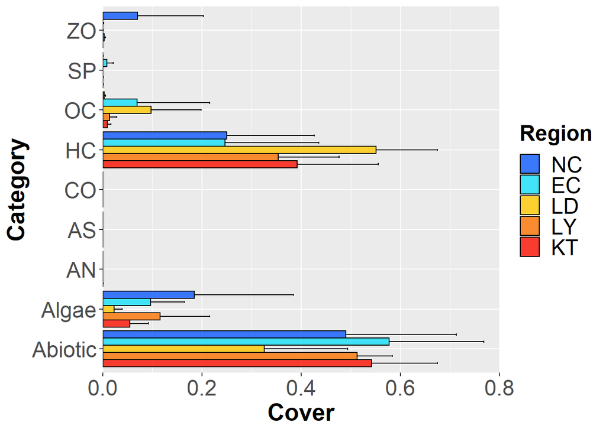

```r
set_region<-c('KT', 'LY', 'LD', 'EC', 'NC')

#Visualize the mean and SD of benthic categories by means of barplot.
bar_by_cat<-ggplot(data= table_merge, aes(y= Category, x=Mean, fill=factor(Region, levels=set_region)))+
  geom_bar(stat="identity", color="black",
           position=position_dodge(), alpha= 0.8)+
  geom_errorbar(aes(x=Mean, y= Category, xmin=Mean, xmax= Mean+SD), width = 0.25,
                position=position_dodge(0.9))+
  xlab('Cover')+
  ylab('Category')+
  labs(fill='Region')+
  scale_fill_manual(values=c("#0c59fe","#15e0fa","#fec700","#fb7200", "#fc0f00"),
                    breaks=c('NC', 'EC', 'LD', 'LY', 'KT'))+
  theme(axis.text=element_text(size=18),
        axis.title=element_text(size=20,face="bold"),
        legend.text = element_text(size = 18),
        legend.title = element_text(size = 18, face='bold'))+
  scale_x_continuous(expand = c(0, 0),
                     limits=c(0, 0.8))

bar_by_cat
```

## Initial selection on benthic categories (sparsity + cross-validation)

Using leave-one-out cross validation to select benthic groups strongly connecting to each complexity metric.

```r
comp_sub_metrics[,3:29]<-decostand(comp_sub_metrics[,3:29], 'hel') #Use hellinger-transformed data to explain complexity
library(glmnet)
filter <- function(x, ...) which(colMeans(x == 0) > 0.5)
sparsity <- function(fraction = 0.7) {
  function(x, ...) which(colMeans(x == 0) > fraction)
}
#V4
cv_V4<-cv.glmnet(y=comp_sub_metrics$`VRM - 4 cm`,
                 x=as.matrix(comp_sub_metrics[,3:29]),
                 exclude=sparsity(0.5),
                 family=gaussian(),
                 nfolds=25)
coef(cv_V4, s='lambda.min')
```

```
## 28 x 1 sparse Matrix of class "dgCMatrix"
##                         s1
## (Intercept)    0.053735182
## actinia        .
## hcarb          0.050277010
## hcbus          0.058709294
## hccol          .
## hcenc          .
## hcfol          .
## hcmas          .
## hctab          .
## ocdig          .
## oclob          0.055406947
## ocmas          .
## fil            0.035538395
## ocbus          .
## ascidian       .
## ocfan          .
## zoaenc         .
## spoglo         .
## spomas         .
## occlu          .
## ocenc          .
## sporep         .
## spopap         .
## coeenc         .
## cru_or_spoenc -0.037221244
## bss           -0.005434893
## ma             .
## us             .
```

```r
V4_coef<-as.data.frame(as.matrix(coef(cv_V4, s='lambda.min')))
#PROC32
cv_PROC32<-cv.glmnet(y=comp_sub_metrics$`PROC - 32 cm`,
                     x=as.matrix(comp_sub_metrics[,3:29]),
                     exclude=sparsity(0.5),
                     family=gaussian(),
                     nfolds=25)
coef(cv_PROC32, s='lambda.min')
```

```
## 28 x 1 sparse Matrix of class "dgCMatrix"
##                       s1
## (Intercept)    0.3974377
## actinia        .
## hcarb          0.2896398
## hcbus          .
## hccol          .
## hcenc          .
## hcfol          .
## hcmas          0.2392364
## hctab          .
## ocdig          .
## oclob          0.1878610
## ocmas          .
## fil           -0.2004176
## ocbus          .
## ascidian       .
## ocfan          .
## zoaenc         .
## spoglo         .
## spomas         .
## occlu          .
## ocenc          .
## sporep         .
## spopap         .
## coeenc         .
## cru_or_spoenc -0.5517123
## bss            .
## ma             0.0390804
## us             0.3011215
```

```r
PROC32_coef<-as.data.frame(as.matrix(coef(cv_PROC32, s='lambda.min')))
#PLC4
cv_PLC4<-cv.glmnet(y=comp_sub_metrics$`PLC - 4 cm`,
                   x=as.matrix(comp_sub_metrics[,3:29]),
                   exclude=sparsity(0.5),
                   family=gaussian(),
                   nfolds=25)
coef(cv_PLC4, s='lambda.min')
```

```
## 28 x 1 sparse Matrix of class "dgCMatrix"
##                     s1
## (Intercept)   14.46766
## actinia        .
## hcarb          .
## hcbus          .
## hccol          .
## hcenc          .
## hcfol          .
## hcmas          .
## hctab          .
## ocdig          .
## oclob          .
## ocmas          .
## fil            .
## ocbus          .
## ascidian       .
## ocfan          .
## zoaenc         .
## spoglo         .
## spomas         .
## occlu          .
## ocenc          .
## sporep         .
## spopap         .
## coeenc         .
## cru_or_spoenc  .
## bss            .
## ma             .
## us             .
```

```r
PLC4_coef<-as.data.frame(as.matrix(coef(cv_PLC4, s='lambda.min')))
#PLC16
cv_PLC16<-cv.glmnet(y=comp_sub_metrics$`PLC - 16 cm`,
                    x=as.matrix(comp_sub_metrics[,3:29]),
                    exclude=sparsity(0.5),
                    family=gaussian(),
                    nfolds=25)
coef(cv_PLC16, s='lambda.min')
```

```
## 28 x 1 sparse Matrix of class "dgCMatrix"
##                      s1
## (Intercept)   3.6861714
## actinia       .
## hcarb         .
## hcbus         .
## hccol         .
## hcenc         0.1278988
## hcfol         .
## hcmas         .
## hctab         .
## ocdig         .
## oclob         .
## ocmas         .
## fil           .
## ocbus         .
## ascidian      .
## ocfan         .
## zoaenc        1.8287842
## spoglo        .
## spomas        .
## occlu         .
## ocenc         .
## sporep        .
## spopap        .
## coeenc        .
## cru_or_spoenc 1.8331015
## bss           .
## ma            .
## us            .
```

```r
PLC16_coef<-as.data.frame(as.matrix(coef(cv_PLC16, s='lambda.min')))
#PLC32
cv_PLC32<-cv.glmnet(y=comp_sub_metrics$`PLC - 32 cm`,
                    x=as.matrix(comp_sub_metrics[,3:29]),
                    exclude=sparsity(0.5),
                    family=gaussian(),
                    nfolds=25)
coef(cv_PLC32, s='lambda.min')
```

```
## 28 x 1 sparse Matrix of class "dgCMatrix"
##                     s1
## (Intercept)   1.983702
## actinia       .
## hcarb         .
## hcbus         .
## hccol         .
## hcenc         .
## hcfol         .
## hcmas         .
## hctab         .
## ocdig         .
## oclob         .
## ocmas         .
## fil           .
## ocbus         .
## ascidian      .
## ocfan         .
## zoaenc        .
## spoglo        .
## spomas        .
## occlu         .
## ocenc         .
## sporep        .
## spopap        .
## coeenc        .
## cru_or_spoenc .
## bss           .
## ma            .
## us            .
```

```r
PLC32_coef<-as.data.frame(as.matrix(coef(cv_PLC32, s='lambda.min')))
#D12
cv_D12<-cv.glmnet(y=comp_sub_metrics$`D (1 - 2 cm)`,
                  x=as.matrix(comp_sub_metrics[,3:29]),
                  exclude=sparsity(0.5),
                  family=gaussian(),
                  nfolds=25)
coef(cv_D12, s='lambda.min')
```

```
## 28 x 1 sparse Matrix of class "dgCMatrix"
##                        s1
## (Intercept)    2.14134241
## actinia        .
## hcarb          0.15288193
## hcbus          0.10988326
## hccol          .
## hcenc         -0.04728306
## hcfol          .
## hcmas          .
## hctab          .
## ocdig          .
## oclob          .
## ocmas          .
## fil            .
## ocbus          0.13645823
## ascidian       .
## ocfan          .
## zoaenc         .
## spoglo         .
## spomas         .
## occlu          .
## ocenc          .
## sporep         .
## spopap         .
## coeenc         .
## cru_or_spoenc  .
## bss           -0.03307469
## ma             .
## us             .
```

```r
D12_coef<-as.data.frame(as.matrix(coef(cv_D12, s='lambda.min')))
#D24
cv_D24<-cv.glmnet(y=comp_sub_metrics$`D (2 - 4 cm)`,
                  x=as.matrix(comp_sub_metrics[,3:29]),
                  exclude=sparsity(0.5),
                  family=gaussian(),
                  nfolds=25)
coef(cv_D24, s='lambda.min')
```

```
## 28 x 1 sparse Matrix of class "dgCMatrix"
##                         s1
## (Intercept)    2.124335869
## actinia        .
## hcarb          0.115316384
## hcbus          0.100490226
## hccol          .
## hcenc         -0.031322852
## hcfol          0.012761308
## hcmas          .
## hctab          .
## ocdig          .
## oclob          0.036082040
## ocmas          .
## fil            .
## ocbus          0.136553257
## ascidian       .
## ocfan          .
## zoaenc         .
## spoglo         .
## spomas         .
## occlu          .
## ocenc          .
## sporep         .
## spopap         .
## coeenc         .
## cru_or_spoenc  .
## bss           -0.006845403
## ma             .
## us            -0.028228542
```

```r
D24_coef<-as.data.frame(as.matrix(coef(cv_D24, s='lambda.min')))
#D816
cv_D816<-cv.glmnet(y=comp_sub_metrics$`D(8 - 16 cm)`,
                   x=as.matrix(comp_sub_metrics[,3:29]),
                   exclude=sparsity(0.5),
                   family=gaussian(),
                   nfolds=25)
coef(cv_D816, s='lambda.min')
```

```
## 28 x 1 sparse Matrix of class "dgCMatrix"
##                     s1
## (Intercept)   2.129821
## actinia       .
## hcarb         .
## hcbus         .
## hccol         .
## hcenc         .
## hcfol         .
## hcmas         .
## hctab         .
## ocdig         .
## oclob         .
## ocmas         .
## fil           .
## ocbus         .
## ascidian      .
## ocfan         .
## zoaenc        .
## spoglo        .
## spomas        .
## occlu         .
## ocenc         .
## sporep        .
## spopap        .
## coeenc        .
## cru_or_spoenc .
## bss           .
## ma            .
## us            .
```

```r
D816_coef<-as.data.frame(as.matrix(coef(cv_D816, s='lambda.min')))
#D1632
cv_D1632<-cv.glmnet(y=comp_sub_metrics$`D(16 - 32 cm)`,
                    x=as.matrix(comp_sub_metrics[,3:29]),
                    exclude=sparsity(0.5),
                    family=gaussian(),
                    nfolds=25)
coef(cv_D1632, s='lambda.min')
```

```
## 28 x 1 sparse Matrix of class "dgCMatrix"
##                         s1
## (Intercept)    2.187122999
## actinia        .
## hcarb          .
## hcbus          .
## hccol          .
## hcenc          .
## hcfol          .
## hcmas          0.009999148
## hctab          .
## ocdig          .
## oclob          0.039038636
## ocmas          .
## fil            .
## ocbus          .
## ascidian       .
## ocfan          .
## zoaenc         .
## spoglo         .
## spomas         .
## occlu          .
## ocenc          .
## sporep         .
## spopap         .
## coeenc         .
## cru_or_spoenc -0.168756594
## bss           -0.077143267
## ma             0.048356310
## us             .
```

```r
D1632_coef<-as.data.frame(as.matrix(coef(cv_D1632, s='lambda.min')))
#D3264
cv_D3264<-cv.glmnet(y=comp_sub_metrics$`D(32 - 64 cm)`,
                    x=as.matrix(comp_sub_metrics[,3:29]),
                    exclude=sparsity(0.5),
                    family=gaussian(),
                    nfolds=25)
coef(cv_D3264, s='lambda.min')
```

```
## 28 x 1 sparse Matrix of class "dgCMatrix"
##                        s1
## (Intercept)    2.28252751
## actinia        .
## hcarb          .
## hcbus          .
## hccol          .
## hcenc          .
## hcfol          .
## hcmas          0.10940723
## hctab          .
## ocdig          0.14210451
## oclob          .
## ocmas          .
## fil           -0.10707590
## ocbus          .
## ascidian       .
## ocfan          .
## zoaenc         .
## spoglo         .
## spomas         .
## occlu          .
## ocenc          .
## sporep         .
## spopap         .
## coeenc         .
## cru_or_spoenc -0.23970285
## bss           -0.10335599
## ma             .
## us             0.07651734
```

```r
D3264_coef<-as.data.frame(as.matrix(coef(cv_D3264, s='lambda.min')))
#Sq
cv_VRSD<-cv.glmnet(y=comp_sub_metrics$Sq,
                   x=as.matrix(comp_sub_metrics[,3:29]),
                   exclude=sparsity(0.5),
                   family=gaussian(),
                   nfolds=25)
coef(cv_VRSD, s='lambda.min')
```

```
## 28 x 1 sparse Matrix of class "dgCMatrix"
##                      s1
## (Intercept)   0.3158596
## actinia       .
## hcarb         .
## hcbus         .
## hccol         .
## hcenc         .
## hcfol         .
## hcmas         .
## hctab         .
## ocdig         .
## oclob         .
## ocmas         .
## fil           .
## ocbus         .
## ascidian      .
## ocfan         .
## zoaenc        .
## spoglo        .
## spomas        .
## occlu         .
## ocenc         .
## sporep        .
## spopap        .
## coeenc        .
## cru_or_spoenc .
## bss           .
## ma            .
## us            0.1544438
```

```r
Sq_coef<-as.data.frame(as.matrix(coef(cv_VRSD, s='lambda.min')))
```

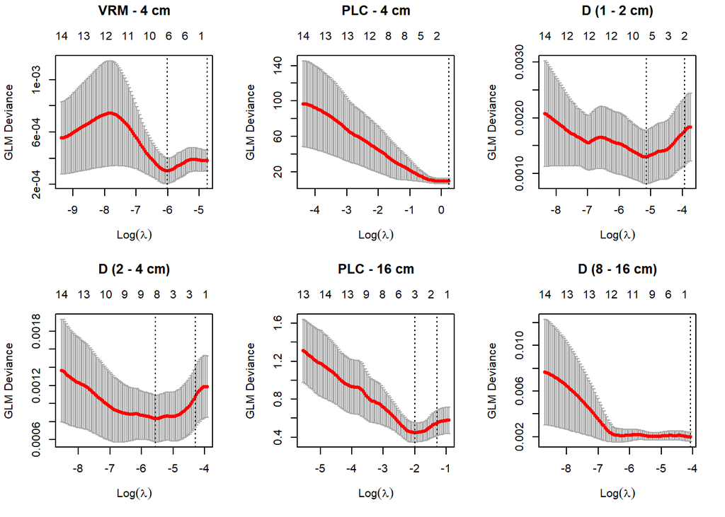

```r
#Show all plots
par(mfrow=c(2,3))
plot(cv_V4)
title('VRM - 4 cm', line= 3)
plot(cv_PLC4)
title('PLC - 4 cm', line = 3)
plot(cv_D12)
title('D (1 - 2 cm)', line = 3)
plot(cv_D24)
title('D (2 - 4 cm)', line = 3)
plot(cv_PLC16)
title('PLC - 16 cm', line = 3)
plot(cv_D816)
title('D (8 - 16 cm)', line = 3)
```

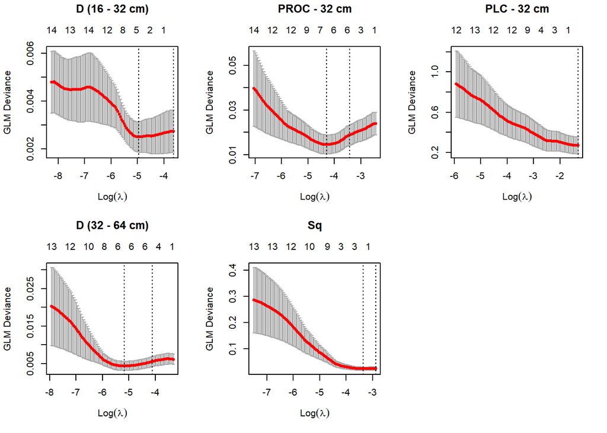

```r
par(mfrow=c(2,3))
plot(cv_D1632)
title('D (16 - 32 cm)', line = 3)
plot(cv_PROC32)
title('PROC - 32 cm', line = 3)
plot(cv_PLC32)
title('PLC - 32 cm', line = 3)
plot(cv_D3264)
title('D (32 - 64 cm)', line = 3)
plot(cv_VRSD)
title('Sq', line = 3)
```

```r
###Show all coefficients
cv_coef<-cbind(V4_coef, PLC4_coef, D12_coef, D24_coef,
      PLC16_coef, D816_coef, D1632_coef,
      PROC32_coef, PLC32_coef, D3264_coef,
      Sq_coef)
colnames(cv_coef)<-c('VRM - 4 cm', 'PLC - 4 cm', 'D (1 - 2 cm)',
'D (2 - 4 cm)', 'PLC - 16 cm', 'D (8 - 16 cm)', 'D (16 - 32 cm)',
'PROC - 32 cm', 'PLC - 32 cm', 'D (32 - 64 cm)', 'Sq'     )
row.names(cv_coef)<-c('Intercept', 'AN', 'Arborescent HC',
                      'Bushy HC', 'Columnar HC', 'Encrusting HC', 'Foliose HC',
                      'Massive HC', 'Tabular HC', 'Digitate OC', 'Lobate OC',
                      'Massive OC', 'TU', 'Bushy OC',
                      'AS', 'Fan OC', 'Encrusting ZO', 'Globular SP',
                      'Massive SP', 'Clustered OC', 'Encrusting OC',
                      'Repent SP', 'Papillate SP', 'CO', 'CCA',
                      'BSS', 'MA', 'US')
cv_coef<-cv_coef[c(1,4,5,7,8,9,11,12,15,16,19,22,28, 29:31 ),]
categories_retained<-row.names(cv_coef)
cv_coef<-cbind(categories_retained,cv_coef)
colnames(cv_coef)[1]<-'Category'
head(cv_coef)
```

```
##                Category VRM - 4 cm PLC - 4 cm D (1 - 2 cm) D (2 - 4 cm)
## Intercept     Intercept 0.05373518   14.46766    2.1413424   2.12433587
## Bushy HC       Bushy HC 0.05870929    0.00000    0.1098833   0.10049023
## Columnar HC Columnar HC 0.00000000    0.00000    0.0000000   0.00000000
## Foliose HC   Foliose HC 0.00000000    0.00000    0.0000000   0.01276131
## Massive HC   Massive HC 0.00000000    0.00000    0.0000000   0.00000000
## Tabular HC   Tabular HC 0.00000000    0.00000    0.0000000   0.00000000
##             PLC - 16 cm D (8 - 16 cm) D (16 - 32 cm) PROC - 32 cm PLC - 32 cm
## Intercept      3.686171      2.129821    2.187122999    0.3974377    1.983702
## Bushy HC       0.000000      0.000000    0.000000000    0.0000000    0.000000
## Columnar HC    0.000000      0.000000    0.000000000    0.0000000    0.000000
## Foliose HC     0.000000      0.000000    0.000000000    0.0000000    0.000000
## Massive HC     0.000000      0.000000    0.009999148    0.2392364    0.000000
## Tabular HC     0.000000      0.000000    0.000000000    0.0000000    0.000000
##             D (32 - 64 cm)        Sq
## Intercept        2.2825275 0.3158596
## Bushy HC         0.0000000 0.0000000
## Columnar HC      0.0000000 0.0000000
## Foliose HC       0.0000000 0.0000000
## Massive HC       0.1094072 0.0000000
## Tabular HC       0.0000000 0.0000000
```

## Second selection (stepwise VIF) and RDA

Using stepwise VIF selection for the second selection on benthic categories.

```r
par(mfrow=c(1,1))
library(dplyr)

comp_sub_hel_std<-decostand(comp_sub_hel, 'standardize')
MetricsRDA_table<-dplyr::select(comp_sub_hel_std,`Arborescent HC`, `Bushy HC`, `Encrusting HC`,
                                `Foliose HC`, `Massive HC`,
                         `Encrusting ZO`,
                         `Lobate OC`, `Digitate OC`,`Bushy OC`, `TU`, `MA`,
                         `CCA`,`BSS`, `US`
)
metrics_std<-decostand(metrics[,c(3,8,9,10,15,18,19,21,22,23,24)], 'standardize')
rda_table<- merge(MetricsRDA_table, metrics_std, by='row.names')
row.names(rda_table)<-rda_table$Row.names
groups<-c('NC', 'NC', 'LY', 'NC', 'LD', 'LD', 'LY', 'KT', 'EC', 'LD', 'LD',
          'KT', 'LY', 'EC', 'EC', 'KT', 'EC', 'EC', 'NC', 'KT', 'NC', 'LD',
          'LY', 'KT', 'LY')
rda_table<-rda_table[,-1]
rda_mod<-rda(rda_table[,c(15:25)]~., data=rda_table[,1:14])
rda_mod_summary<-summary(rda_mod)
vif.cca(rda_mod)
```

```
## `Arborescent HC`       `Bushy HC`  `Encrusting HC`     `Foliose HC`
##         2.620946         2.124510         3.477926         6.729359
##     `Massive HC`  `Encrusting ZO`      `Lobate OC`    `Digitate OC`
##        10.971110         2.240089         4.739942         3.302177
##       `Bushy OC`               TU               MA              CCA
##         4.514903         1.731663         5.603664         3.008834
##              BSS               US
##        14.504586         2.772545
```

```r
#remove BSS
MetricsRDA_table<-dplyr::select(comp_sub_hel_std,`Arborescent HC`, `Bushy HC`, `Encrusting HC`,
                                `Foliose HC`, `Massive HC`,
                                `Encrusting ZO`,
                                `Lobate OC`, `Digitate OC`,`Bushy OC`, `TU`, `MA`,
                                `CCA`, `US`
)
metrics_std<-decostand(metrics[,c(3,8,9,10,15,18,19,21,22,23,24)], 'standardize')
rda_table<- merge(MetricsRDA_table, metrics_std, by='row.names')
row.names(rda_table)<-rda_table$Row.names
groups<-c('NC', 'NC', 'LY', 'NC', 'LD', 'LD', 'LY', 'KT', 'EC', 'LD', 'LD',
          'KT', 'LY', 'EC', 'EC', 'KT', 'EC', 'EC', 'NC', 'KT', 'NC', 'LD',
          'LY', 'KT', 'LY')
groups2<-as.factor(groups)
levels(groups2)<-my_cols
rda_table<-rda_table[,-1]
rda_mod<-rda(rda_table[,c(14:24)]~., data=rda_table[,1:13])
rda_mod_summary<-summary(rda_mod)
vif.cca(rda_mod) #All VIF <10
```

```
## `Arborescent HC`       `Bushy HC`  `Encrusting HC`     `Foliose HC`
##         2.550641         1.886092         3.347802         2.590482
##     `Massive HC`  `Encrusting ZO`      `Lobate OC`    `Digitate OC`
##         3.477530         1.976133         4.376459         2.995125
##       `Bushy OC`               TU               MA              CCA
##         3.510448         1.548344         5.207802         2.569749
##               US
##         2.478443
```

```r
#Visualization
#Show R^2
RsquareAdj(rda_mod)
```

```
## $r.squared
## [1] 0.6991858
##
## $adj.r.squared
## [1] 0.3436782
```

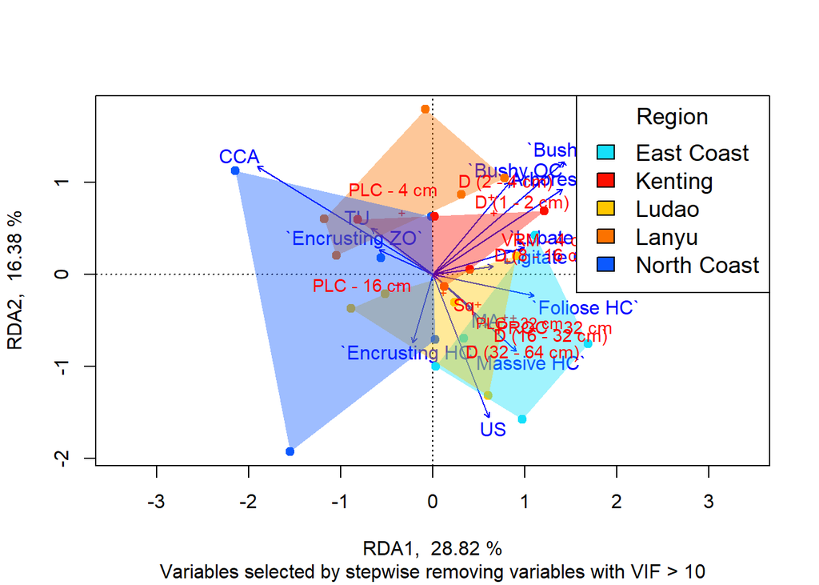

```r
#Show biplot of RDA
ordiplot(rda_mod,type = 'p',
         xlab=paste('RDA1, ',
                    round(rda_mod_summary$cont$importance[2,1]*100, 2), '%'),
         ylab=paste('RDA2, ',round(rda_mod_summary$cont$importance[2,2]*100, 2), '%'),
         xlim=c(-1,1),
         cex=0.8)
title(
      sub='Variables selected by stepwise removing variables with VIF > 10')

rda_sc<-scores(rda_mod,choice=1:2,
               display='sp')



rda_sc1<-scores(rda_mod,choice=1:2,
               display='site')

points(x=rda_sc1[,1], y=rda_sc1[,2], pch=20, cex=1.5,
       col=as.vector(groups2))

ordihull(rda_mod,
         groups= groups,
         draw='polygon',
         alpha=0.4,

         col=my_cols,
         border = NA)



text(x=rda_sc[1,1]+0.3,
     y=rda_sc[1,2]+0.02,
     'VRM - 4 cm',
     cex=0.9,
     col='red')
text(x=rda_sc[2,1]-0.1,
     y=rda_sc[2,2]+0.25,
     'PLC - 4 cm',
     cex=0.9,
     col='red')
text(x=rda_sc[3,1]+0.45,
     y=rda_sc[3,2]-0.1,
     'PROC - 32 cm',
     cex=0.9,
     col='red')
text(x=rda_sc[4,1]+0.45,
     y=rda_sc[4,2]-0.2,
     'PLC - 32 cm',
     cex=0.8,
     col='red')
text(x=rda_sc[5,1]-0.4,
     y=rda_sc[5,2],
     'PLC - 16 cm',
     cex=0.9,
     col='red')
text(x=rda_sc[6,1]+0.3,
     y=rda_sc[6,2]+0.1,
     'D (1 - 2 cm)',
     cex=0.9,
     col='red')
text(x=rda_sc[7,1]+0.15,
     y=rda_sc[7,2]+0.15,
     'D (2 - 4 cm)',
     cex=0.9,
     col='red')

text(x=rda_sc[8,1]+0.42,
     y=rda_sc[8,2]+0.05,
     'D (8 - 16 cm)',
     cex=0.9,
     col='red')
text(x=rda_sc[9,1]+0.5,
     y=rda_sc[9,2]-0.21,
     'D (16 - 32 cm)',
     cex=0.9,
     col='red')
text(x=rda_sc[10,1]+0.4,
     y=rda_sc[10,2]-0.31,
     'D (32 - 64 cm)',
     cex=0.9,
     col='red')
text(x=rda_sc[11,1]+0.22,
     y=rda_sc[11,2]-0.15,
     'Sq',
     cex=0.9,
     col='red')
legend('topright', fill=my_cols,
       legend= c('East Coast','Kenting', 'Ludao', 'Lanyu', 'North Coast'),
       title='Region',
       cex=1.2)
```

```r
#Show summary of the constrained model
rda_mod_summary
```

```
##
## Call:
## rda(formula = rda_table[, c(14:24)] ~ `Arborescent HC` + `Bushy HC` +      `Encrusting HC` + `Foliose HC` + `Massive HC` + `Encrusting ZO` +      `Lobate OC` + `Digitate OC` + `Bushy OC` + TU + MA + CCA +      US, data = rda_table[, 1:13])
##
## Partitioning of variance:
##               Inertia Proportion
## Total          11.000     1.0000
## Constrained     7.691     0.6992
## Unconstrained   3.309     0.3008
##
## Eigenvalues, and their contribution to the variance
##
## Importance of components:
##                         RDA1   RDA2    RDA3    RDA4    RDA5    RDA6     RDA7
## Eigenvalue            3.1697 1.8014 1.00331 0.84767 0.39241 0.22757 0.096024
## Proportion Explained  0.2882 0.1638 0.09121 0.07706 0.03567 0.02069 0.008729
## Cumulative Proportion 0.2882 0.4519 0.54313 0.62019 0.65587 0.67656 0.685285
##                           RDA8    RDA9    RDA10     RDA11    PC1     PC2
## Eigenvalue            0.080485 0.04576 0.022710 0.0039542 1.6582 0.68247
## Proportion Explained  0.007317 0.00416 0.002065 0.0003595 0.1507 0.06204
## Cumulative Proportion 0.692602 0.69676 0.698826 0.6991858 0.8499 0.91198
##                           PC3     PC4     PC5     PC6      PC7      PC8
## Eigenvalue            0.41176 0.21142 0.12513 0.11517 0.046177 0.032323
## Proportion Explained  0.03743 0.01922 0.01138 0.01047 0.004198 0.002938
## Cumulative Proportion 0.94941 0.96863 0.98000 0.99047 0.994671 0.997609
##                            PC9      PC10      PC11
## Eigenvalue            0.016776 0.0085994 9.242e-04
## Proportion Explained  0.001525 0.0007818 8.402e-05
## Cumulative Proportion 0.999134 0.9999160 1.000e+00
##
## Accumulated constrained eigenvalues
## Importance of components:
##                         RDA1   RDA2   RDA3   RDA4    RDA5    RDA6    RDA7
## Eigenvalue            3.1697 1.8014 1.0033 0.8477 0.39241 0.22757 0.09602
## Proportion Explained  0.4121 0.2342 0.1305 0.1102 0.05102 0.02959 0.01249
## Cumulative Proportion 0.4121 0.6464 0.7768 0.8870 0.93804 0.96763 0.98012
##                          RDA8    RDA9    RDA10     RDA11
## Eigenvalue            0.08049 0.04576 0.022710 0.0039542
## Proportion Explained  0.01046 0.00595 0.002953 0.0005141
## Cumulative Proportion 0.99058 0.99653 0.999486 1.0000000
```

[output cut: 84 more lines]

```
##
##                      RDA1     RDA2      RDA3     RDA4     RDA5      RDA6
## `Arborescent HC`  0.48241  0.31641 -0.185387  0.12083 -0.40216  0.192197
## `Bushy HC`        0.49008  0.41858 -0.216769  0.06204  0.03530 -0.024141
## `Encrusting HC`  -0.07407 -0.25485 -0.053189  0.12496 -0.32067 -0.145355
## `Foliose HC`      0.37766 -0.07987 -0.350386  0.08564  0.04680  0.038101
## `Massive HC`      0.31084 -0.28588  0.063616 -0.25818 -0.61056 -0.050958
## `Encrusting ZO`  -0.20046  0.09090  0.647300  0.08155 -0.43712  0.148335
## `Lobate OC`       0.34130  0.09892  0.097400  0.03851 -0.03408  0.005006
## `Digitate OC`     0.22411  0.03020  0.227611  0.26406  0.07525  0.319740
## `Bushy OC`        0.28658  0.34216 -0.237100  0.03434 -0.14611 -0.021914
## TU               -0.22788  0.17118  0.705175 -0.34350  0.11847 -0.172946
## MA                0.15065 -0.13055  0.179308  0.22432  0.29762  0.038170
## CCA              -0.65215  0.40235  0.147208  0.20643 -0.45647 -0.016546
## US                0.20871 -0.53409 -0.007658 -0.41181  0.06656  0.298473
```

```r
#Show the scores of RDA1 and RDA2
rda_sc2<-scores(rda_mod,choice=1:2,
                display = 'bp')
rda_scores<-as.data.frame(rda_sc2)
rda_scores<-round(rda_scores, 3)
rda_scores$Groups<-row.names(rda_scores)
rda_scores<-dplyr::select(rda_scores, Groups, RDA1, RDA2)
library(gt)
rda_scores_gt<-gt(rda_scores)
rda_scores_gt
```

| Groups | RDA1 | RDA2 |
| --- | --- | --- |
| `Arborescent HC` | 0.482 | 0.316 |
| `Bushy HC` | 0.490 | 0.419 |
| `Encrusting HC` | -0.074 | -0.255 |
| `Foliose HC` | 0.378 | -0.080 |
| `Massive HC` | 0.311 | -0.286 |
| `Encrusting ZO` | -0.200 | 0.091 |
| `Lobate OC` | 0.341 | 0.099 |
| `Digitate OC` | 0.224 | 0.030 |
| `Bushy OC` | 0.287 | 0.342 |
| TU | -0.228 | 0.171 |
| MA | 0.151 | -0.131 |
| CCA | -0.652 | 0.402 |
| US | 0.209 | -0.534 |

```r
###############Check significance of RDA model##############
#Check the significance by axis
set.seed(123)
rda_aov<-anova.cca(rda_mod, by='axis',
                   permutations = how(nperm=999))
rda_aov
```

```
## Permutation test for rda under reduced model
## Forward tests for axes
## Permutation: free
## Number of permutations: 999
##
## Model: rda(formula = rda_table[, c(14:24)] ~ `Arborescent HC` + `Bushy HC` + `Encrusting HC` + `Foliose HC` + `Massive HC` + `Encrusting ZO` + `Lobate OC` + `Digitate OC` + `Bushy OC` + TU + MA + CCA + US, data = rda_table[, 1:13])
##          Df Variance       F Pr(>F)
## RDA1      1   3.1697 12.4529  0.012 *
## RDA2      1   1.8014  7.0773  0.181
## RDA3      1   1.0033  3.9417  0.834
## RDA4      1   0.8477  3.3303  0.915
## RDA5      1   0.3924  1.5417  0.998
## RDA6      1   0.2276  0.8941  1.000
## RDA7      1   0.0960  0.3773  1.000
## RDA8      1   0.0805  0.3162  1.000
## RDA9      1   0.0458  0.1798  1.000
## RDA10     1   0.0227  0.0892  1.000
## RDA11     1   0.0040  0.0155  1.000
## Residual 13   3.3090
## ---
## Signif. codes:  0 '***' 0.001 '**' 0.01 '*' 0.05 '.' 0.1 ' ' 1
```

```r
#Significance at RDA1

#Check significance by terms
rda_aov_term<-anova.cca(rda_mod, by='term',
          permutations = how(nperm=999))
rda_aov_term
```

```
## Permutation test for rda under reduced model
## Terms added sequentially (first to last)
## Permutation: free
## Number of permutations: 999
##
## Model: rda(formula = rda_table[, c(14:24)] ~ `Arborescent HC` + `Bushy HC` + `Encrusting HC` + `Foliose HC` + `Massive HC` + `Encrusting ZO` + `Lobate OC` + `Digitate OC` + `Bushy OC` + TU + MA + CCA + US, data = rda_table[, 1:13])
##                  Df Variance      F Pr(>F)
## `Arborescent HC`  1   1.0533 3.5013  0.007 **
## `Bushy HC`        1   0.5134 1.7066  0.143
## `Encrusting HC`   1   0.4183 1.3905  0.250
## `Foliose HC`      1   0.5179 1.7216  0.120
## `Massive HC`      1   0.6731 2.2376  0.049 *
## `Encrusting ZO`   1   0.5797 1.9271  0.097 .
## `Lobate OC`       1   0.7846 2.6082  0.060 .
## `Digitate OC`     1   0.2483 0.8255  0.521
## `Bushy OC`        1   0.5292 1.7593  0.123
## TU                1   0.6691 2.2243  0.065 .
## MA                1   1.0111 3.3612  0.009 **
## CCA               1   0.3042 1.0114  0.428
## US                1   0.3889 1.2929  0.267
## Residual         11   3.3090
## ---
## Signif. codes:  0 '***' 0.001 '**' 0.01 '*' 0.05 '.' 0.1 ' ' 1
```

```r
#Check significance of the whole constrained model
rda_aov_all<-anova.cca(rda_mod,permutations = how(nperm=999)) #Show overall significance
rda_aov_all
```

```
## Permutation test for rda under reduced model
## Permutation: free
## Number of permutations: 999
##
## Model: rda(formula = rda_table[, c(14:24)] ~ `Arborescent HC` + `Bushy HC` + `Encrusting HC` + `Foliose HC` + `Massive HC` + `Encrusting ZO` + `Lobate OC` + `Digitate OC` + `Bushy OC` + TU + MA + CCA + US, data = rda_table[, 1:13])
##          Df Variance      F Pr(>F)
## Model    13    7.691 1.9667  0.004 **
## Residual 11    3.309
## ---
## Signif. codes:  0 '***' 0.001 '**' 0.01 '*' 0.05 '.' 0.1 ' ' 1
```

```r
#Significantly tells the variation


#######################################
```